# Seed mass index in FWS refuges

Emilio A. Laca

13 Feb 2022

## Notes

This document shows the results for all units in all refuges measured each year. The document provides a few points of view of the results, for example, some graphs and tables. All data are saved in files and you can format and view them in any desired way. However, the files are too large to sync with GitHub, so you have to run the code in your computer.

To make the files with all output those files, pull everything from github and open the markdown that created this output:

WHAPDataAnalysis/SimBasedEstimates/WHAP_sim_stats.Rmd.

Go to the “read_rds” chunk and set it to eval=FALSE. Go to the “sims” chunk and set it to eval=TRUE. Knit.

Output files will be in the outputFiles folder and their names should be evident in the “sims” shunk.

## Cumulative seed head mass index

Caption:

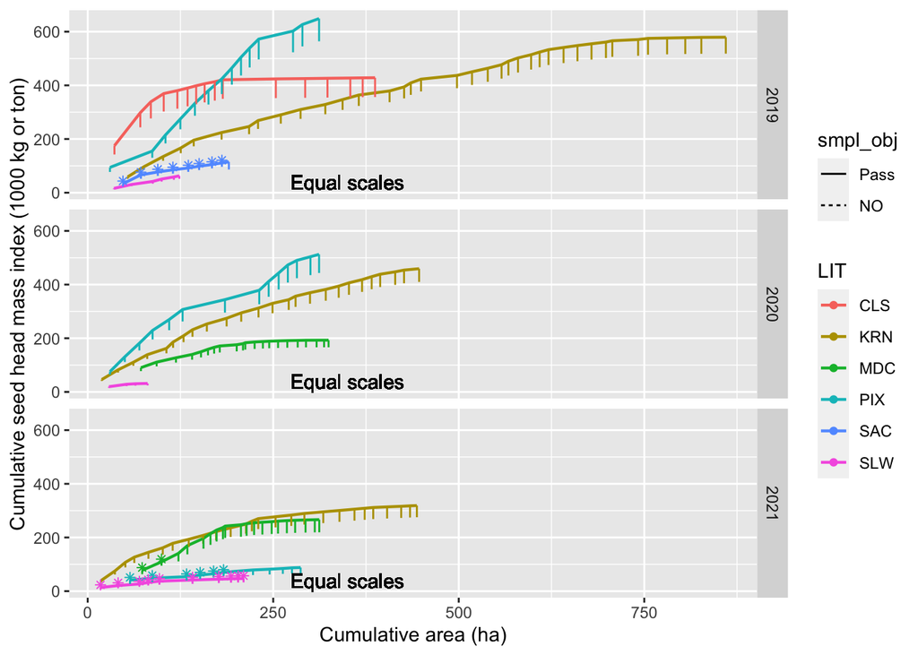

## Bigger figures of the same data

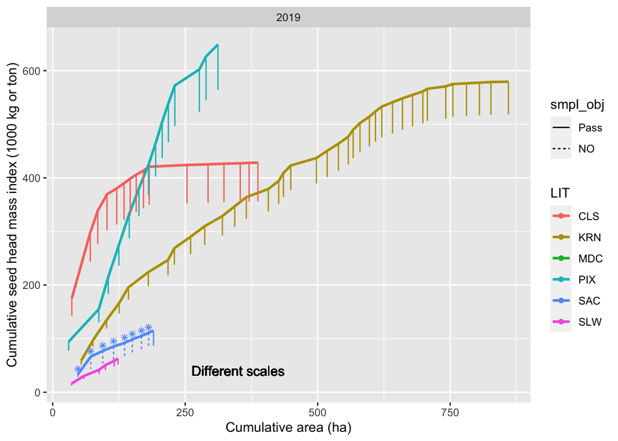

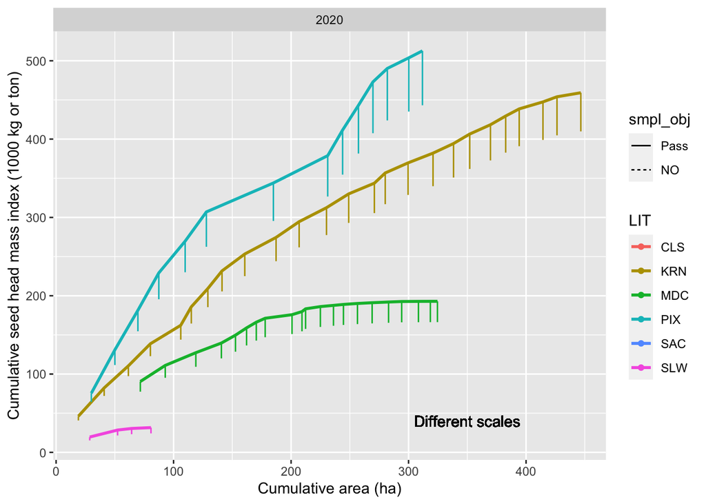

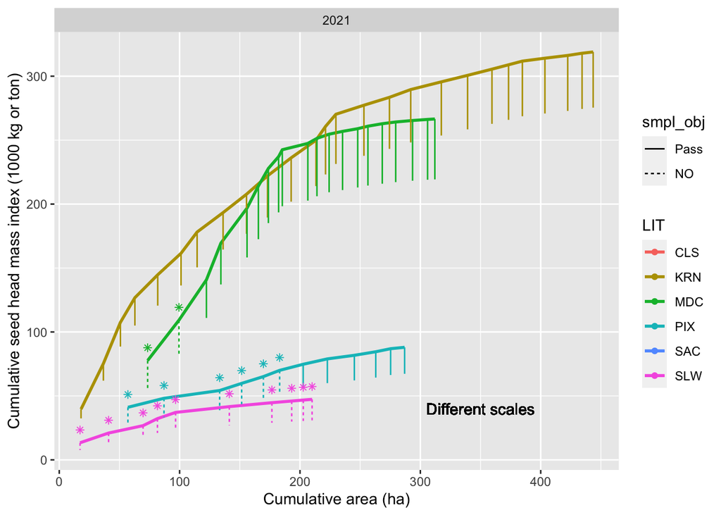

## Cumulative tables

These tables contain the data used for the figures above. Each unit that has a values equal to “Pass” in the last column meets sampling objectives. Each refuge whose last unit has a value equal to “Pass” also meets sampling objectives. Cumulative mass is calculated by adding mas contributed by each unit within refuges after units are sorted within refuges in decreasing order of total mass contributed.

The following definitions apply to the next three tables:

Unit: identification code for management subunit.

RtCI90_lwr (ton): Lower boundary above which 90% of the sampling distribution of cumulative seed head mass index lies. This is a non-central confidence interval that ranges from RtCI90_lwr to plus infinity.

CI90lwr (ton): Lower boundary of the central 90% confidence interval for the cumulative seed head mass index.

Cumulative Mass (ton): Estimated total seed mass index in all units above and in the line considered. For example, it is estimated that units CLS_T13A_T13A, CLS_T17_T17 and CLS_T15_T15:1 had a total of 339 tons of seed head mass index in 2019. 339 is teh value located in the line for CLS_T15_T15:1 and the column labeled Cumulative Mass (ton).

CI90upr (ton): Upper boundary of the central 90% confidence interval for the cumulative seed mass index.

Cumulative Area (ha): Total area of all units above and in the line considered.

Objective: Indicator of whether the unit meets the desired precision according to sampling objectives.

Mass (g/m2): Estimated seed head mass index per unit area in the subunit.

SE (g/m2): Standard error of the previous column.

CI90lwr (g/m2): Lower boundary of the central 90% confidence interval for the estimated seed head mass index per unit area in the subunit.

CI90upr (g/m2): Upper boundary of the central 90% confidence interval for the estimated seed head mass index per unit area in the subunit.

Cumulative and individual unit seed head mass index for all species in 2019 (g/m2)

| Unit | RtCI90_lwr (ton) | CI90lwr (ton) | Cumulative Mass (ton) | CI90upr (ton) | MOE/Mean | Cumulative Area (ha) | Objective | Mass (g/m2) | SE (g/m2) | CI90lwr (g/m2) | CI90upr (g/m2) |
| --- | --- | --- | --- | --- | --- | --- | --- | --- | --- | --- | --- |
| CLS_T13A_T13A | 142 | 134 | 175 | 221 | 0.19 | 36 | Pass | 486 | 74.0 | 372 | 613 |
| CLS_T17_T17 | 244 | 230 | 298 | 374 | 0.18 | 71 | Pass | 353 | 53.5 | 272 | 448 |
| CLS_T15_T15:1 | 277 | 263 | 339 | 424 | 0.18 | 85 | Pass | 286 | 45.8 | 217 | 368 |
| CLS_T10_T10:3 | 302 | 288 | 369 | 461 | 0.18 | 102 | Pass | 176 | 23.3 | 141 | 217 |
| CLS_T6_T6:3 | 313 | 298 | 380 | 474 | 0.18 | 121 | Pass | 60 | 6.7 | 50 | 72 |
| CLS_T6_T6:2 | 322 | 307 | 390 | 484 | 0.17 | 135 | Pass | 70 | 6.8 | 59 | 82 |
| CLS_T6_T6:4 | 329 | 315 | 398 | 494 | 0.17 | 146 | Pass | 73 | 6.9 | 62 | 85 |
| CLS_T24_T24:5 | 336 | 321 | 406 | 502 | 0.17 | 158 | Pass | 67 | 7.6 | 55 | 80 |
| CLS_T24_T24:4 | 343 | 328 | 413 | 510 | 0.17 | 171 | Pass | 55 | 6.4 | 45 | 66 |
| CLS_T6_T6:1 | 350 | 335 | 421 | 518 | 0.17 | 182 | Pass | 68 | 7.8 | 56 | 82 |
| CLS_T27_T27.3 | 353 | 337 | 424 | 522 | 0.17 | 254 | Pass | 5 | 1.0 | 3 | 6 |
| CLS_T5_T5 | 354 | 338 | 425 | 524 | 0.17 | 293 | Pass | 3 | 0.6 | 2 | 4 |
| CLS_T15_T15:3 | 354 | 339 | 426 | 525 | 0.17 | 323 | Pass | 4 | 0.7 | 3 | 5 |
| CLS_T15_T15:4 | 355 | 340 | 427 | 526 | 0.17 | 354 | Pass | 3 | 0.5 | 2 | 4 |
| CLS_T15_T15:2 | 356 | 341 | 428 | 527 | 0.17 | 371 | Pass | 4 | 0.8 | 3 | 6 |
| CLS_T6A_T6A | 356 | 341 | 428 | 528 | 0.17 | 387 | Pass | 3 | 0.5 | 2 | 4 |
| KRN_14_14G-1 | 52 | 50 | 59 | 69 | 0.12 | 54 | Pass | 109 | 10.9 | 92 | 128 |
| KRN_4A_4A-5 | 85 | 82 | 97 | 112 | 0.12 | 76 | Pass | 173 | 18.5 | 144 | 206 |
| KRN_4B_4B-1 | 119 | 115 | 135 | 155 | 0.12 | 102 | Pass | 146 | 14.2 | 124 | 171 |
| KRN_14_14C-2 | 147 | 142 | 167 | 194 | 0.12 | 125 | Pass | 134 | 19.2 | 105 | 170 |
| KRN_4A_4A-2 | 173 | 167 | 196 | 227 | 0.12 | 143 | Pass | 167 | 17.5 | 140 | 198 |
| KRN_14_14C-1 | 198 | 191 | 224 | 261 | 0.12 | 180 | Pass | 76 | 12.1 | 57 | 97 |
| KRN_14_14B-2 | 218 | 211 | 247 | 287 | 0.12 | 218 | Pass | 61 | 8.6 | 47 | 76 |
| KRN_5B_5B-7 | 238 | 230 | 269 | 312 | 0.12 | 230 | Pass | 184 | 18.3 | 155 | 216 |
| KRN_14_14B-1 | 257 | 249 | 290 | 335 | 0.11 | 260 | Pass | 70 | 8.1 | 57 | 83 |
| KRN_4A_4A-6 | 275 | 266 | 310 | 358 | 0.11 | 287 | Pass | 74 | 7.9 | 62 | 88 |
| KRN_14_14D-1 | 292 | 283 | 329 | 379 | 0.11 | 320 | Pass | 57 | 9.1 | 43 | 72 |
| KRN_5B_5B-3 | 309 | 299 | 347 | 400 | 0.11 | 343 | Pass | 78 | 9.0 | 64 | 94 |
| KRN_6A_6A-1 | 323 | 313 | 364 | 420 | 0.11 | 365 | Pass | 78 | 10.1 | 62 | 95 |
| KRN_14_14-F | 337 | 326 | 379 | 437 | 0.11 | 407 | Pass | 37 | 7.7 | 25 | 51 |

[output cut: 52 more lines]

Cumulative and individual unit seed head mass index for all species in 2020 (g/m2)

| Unit | RtCI90_lwr (ton) | CI90lwr (ton) | Cumulative Mass (ton) | CI90upr (ton) | MOE/Mean | Cumulative Area (ha) | Objective | Mass (g/m2) | SE (g/m2) | CI90lwr (g/m2) | CI90upr (g/m2) |
| --- | --- | --- | --- | --- | --- | --- | --- | --- | --- | --- | --- |
| KRN_4B_4B-3 | 41 | 39 | 46 | 54 | 0.12 | 19 | Pass | 243 | 23.2 | 207 | 283 |
| KRN_4A_4A-5 | 72 | 69 | 82 | 97 | 0.12 | 41 | Pass | 165 | 20.9 | 132 | 201 |
| KRN_4A_4A-4 | 97 | 94 | 110 | 129 | 0.12 | 62 | Pass | 137 | 12.3 | 118 | 158 |
| KRN_5A_5A-1 | 123 | 119 | 139 | 161 | 0.11 | 80 | Pass | 150 | 12.9 | 130 | 172 |
| KRN_4B_4B-1 | 144 | 139 | 162 | 188 | 0.11 | 106 | Pass | 91 | 8.9 | 77 | 106 |
| KRN_4A_4A-3 | 164 | 159 | 186 | 216 | 0.11 | 115 | Pass | 263 | 27.2 | 220 | 310 |
| KRN_5A_5A-6 | 185 | 179 | 209 | 243 | 0.11 | 129 | Pass | 166 | 15.0 | 142 | 192 |
| KRN_5B_5B-7 | 206 | 199 | 232 | 269 | 0.11 | 141 | Pass | 187 | 17.5 | 160 | 217 |
| KRN_5B_5B-8 | 225 | 217 | 253 | 293 | 0.11 | 161 | Pass | 111 | 9.4 | 97 | 127 |
| KRN_4A_4A-6 | 244 | 236 | 274 | 317 | 0.11 | 187 | Pass | 80 | 7.9 | 67 | 93 |
| KRN_5A_5A-7 | 262 | 253 | 295 | 340 | 0.11 | 207 | Pass | 102 | 13.4 | 82 | 126 |
| KRN_5B_5B-3 | 277 | 269 | 312 | 361 | 0.11 | 230 | Pass | 77 | 11.2 | 60 | 96 |
| KRN_5A_5A-4 | 293 | 284 | 330 | 382 | 0.11 | 249 | Pass | 93 | 10.9 | 76 | 112 |
| KRN_6A_6A-1 | 306 | 296 | 344 | 397 | 0.11 | 271 | Pass | 63 | 5.3 | 54 | 72 |
| KRN_5B_5B-1 | 317 | 307 | 357 | 412 | 0.11 | 280 | Pass | 141 | 13.5 | 120 | 165 |
| KRN_4A_4A-1 | 329 | 318 | 370 | 427 | 0.11 | 300 | Pass | 66 | 6.6 | 56 | 78 |
| KRN_5A_5A-3 | 340 | 329 | 382 | 441 | 0.11 | 321 | Pass | 58 | 5.8 | 50 | 68 |
| KRN_4A_4A-2 | 351 | 340 | 394 | 456 | 0.11 | 338 | Pass | 70 | 11.2 | 53 | 90 |
| KRN_6A_6A-5 | 362 | 350 | 406 | 469 | 0.11 | 352 | Pass | 88 | 7.0 | 77 | 100 |
| KRN_4B_4B-2 | 373 | 360 | 418 | 483 | 0.11 | 370 | Pass | 67 | 6.2 | 58 | 78 |
| KRN_5B_5B-6 | 383 | 370 | 429 | 496 | 0.11 | 383 | Pass | 86 | 7.0 | 75 | 98 |
| KRN_6A_6A-4 | 391 | 378 | 439 | 506 | 0.11 | 394 | Pass | 79 | 6.7 | 69 | 91 |
| KRN_6A_6A-2 | 399 | 386 | 448 | 516 | 0.11 | 414 | Pass | 44 | 5.2 | 36 | 53 |
| KRN_5B_5B-2 | 405 | 392 | 454 | 523 | 0.11 | 426 | Pass | 55 | 4.7 | 47 | 63 |
| KRN_5B_5B-5 | 410 | 396 | 459 | 529 | 0.11 | 447 | Pass | 25 | 3.2 | 20 | 31 |
| MDC_Duck Ponds_Duck Ponds | 78 | 74 | 90 | 108 | 0.14 | 72 | Pass | 126 | 14.5 | 104 | 151 |
| MDC_Upper Goose Pond_Upper Goose Pond | 95 | 91 | 111 | 133 | 0.14 | 93 | Pass | 97 | 13.0 | 77 | 120 |
| MDC_Gadwall_Gadwall | 109 | 105 | 127 | 153 | 0.14 | 119 | Pass | 62 | 8.8 | 49 | 78 |
| MDC_Flournoy Pond_Flournoy Pond | 120 | 115 | 140 | 167 | 0.14 | 141 | Pass | 57 | 8.6 | 44 | 72 |
| MDC_Matney 3_Matney 3 | 129 | 124 | 150 | 179 | 0.14 | 153 | Pass | 84 | 11.6 | 66 | 104 |
| MDC_Matney 6_Matney 6 | 137 | 131 | 159 | 190 | 0.14 | 162 | Pass | 98 | 12.8 | 79 | 121 |
| MDC_Matney 4 North_Matney 4 North | 143 | 137 | 166 | 199 | 0.14 | 170 | Pass | 88 | 11.0 | 71 | 107 |
| MDC_Matney 4 South_Matney 4 South | 147 | 142 | 171 | 205 | 0.14 | 178 | Pass | 66 | 9.0 | 53 | 82 |
| MDC_J Pond_J Pond | 151 | 145 | 176 | 210 | 0.14 | 201 | Pass | 20 | 2.6 | 16 | 24 |
| MDC_South Dam Pond_South Dam Pond | 155 | 149 | 180 | 214 | 0.14 | 209 | Pass | 47 | 6.7 | 36 | 59 |
| MDC_House Field_House Field | 158 | 152 | 183 | 219 | 0.14 | 212 | Pass | 114 | 13.0 | 94 | 136 |
| MDC_Matney 8_Matney 8 | 160 | 154 | 186 | 222 | 0.14 | 225 | Pass | 23 | 3.5 | 18 | 29 |
| MDC_Grandma Tract 9_Grandma Tract 9 | 162 | 155 | 188 | 224 | 0.14 | 236 | Pass | 14 | 3.1 | 9 | 19 |
| MDC_Grandma Tract 2_Grandma Tract 2 | 163 | 156 | 189 | 225 | 0.14 | 245 | Pass | 14 | 2.4 | 11 | 19 |
| MDC_Grandma Tract 4_Grandma Tract 4 | 164 | 158 | 190 | 227 | 0.14 | 257 | Pass | 10 | 2.0 | 7 | 14 |
| MDC_Grandma Tract 3_Grandma Tract 3 | 165 | 158 | 191 | 228 | 0.14 | 269 | Pass | 8 | 1.6 | 5 | 11 |
| MDC_Grandma Tract 10_Grandma Tract 10 | 165 | 159 | 192 | 229 | 0.14 | 283 | Pass | 6 | 0.8 | 5 | 8 |
| MDC_Grandma Tract 8_Grandma Tract 8 | 166 | 160 | 193 | 230 | 0.14 | 294 | Pass | 6 | 0.8 | 5 | 7 |
| MDC_Grandma Tract 7_Grandma Tract 7 | 166 | 160 | 193 | 230 | 0.14 | 308 | Pass | 1 | 0.3 | 1 | 2 |
| MDC_Matney 7_Matney 7 | 166 | 160 | 193 | 230 | 0.14 | 319 | Pass | 1 | 0.1 | 0 | 1 |
| MDC_Grandma Tract 11_Grandma Tract 11 | 166 | 160 | 193 | 230 | 0.14 | 325 | Pass | 1 | 0.1 | 0 | 1 |
| PIX_3A_3A | 64 | 62 | 76 | 91 | 0.15 | 30 | Pass | 252 | 30.0 | 206 | 304 |
| PIX_2_2 | 112 | 107 | 131 | 158 | 0.15 | 50 | Pass | 276 | 33.0 | 225 | 333 |
| PIX_3_3 | 155 | 149 | 181 | 219 | 0.15 | 70 | Pass | 258 | 30.5 | 211 | 312 |
| PIX_8B_8B | 196 | 188 | 229 | 277 | 0.15 | 87 | Pass | 268 | 31.1 | 221 | 323 |
| PIX_2A_2A | 230 | 221 | 270 | 326 | 0.15 | 110 | Pass | 181 | 21.2 | 149 | 218 |
| PIX_4_4 | 263 | 253 | 307 | 370 | 0.15 | 128 | Pass | 207 | 22.1 | 173 | 245 |
| PIX_1_1 | 295 | 285 | 344 | 413 | 0.14 | 185 | Pass | 65 | 7.1 | 54 | 77 |
| PIX_6_6 | 327 | 314 | 379 | 452 | 0.14 | 231 | Pass | 75 | 12.1 | 58 | 97 |
| PIX_7A_7A | 355 | 341 | 412 | 492 | 0.14 | 244 | Pass | 258 | 30.5 | 211 | 311 |
| PIX_9B_9B | 382 | 367 | 443 | 529 | 0.14 | 257 | Pass | 234 | 26.2 | 194 | 280 |
| PIX_9A_9A | 408 | 392 | 473 | 565 | 0.14 | 270 | Pass | 243 | 26.8 | 202 | 289 |
| PIX_7B_7B | 424 | 408 | 490 | 584 | 0.14 | 282 | Pass | 141 | 43.8 | 80 | 218 |
| PIX_4A_4A | 435 | 419 | 504 | 600 | 0.14 | 300 | Pass | 74 | 22.8 | 43 | 118 |
| PIX_8A_8A | 443 | 427 | 513 | 610 | 0.14 | 312 | Pass | 77 | 25.1 | 42 | 124 |
| SLW_LIC_57 | 15 | 14 | 20 | 26 | 0.22 | 29 | Pass | 68 | 12.6 | 50 | 91 |
| SLW_Lewis 6_22 | 22 | 20 | 29 | 39 | 0.24 | 52 | Pass | 38 | 14.7 | 19 | 66 |
| SLW_Lewis 1_22 | 23 | 22 | 31 | 41 | 0.24 | 64 | Pass | 17 | 3.7 | 12 | 24 |
| SLW_Beach Lake 1_Beach Lake 1 | 24 | 23 | 32 | 43 | 0.23 | 81 | Pass | 7 | 1.4 | 5 | 9 |

Cumulative and individual unit seed head mass index for all species in 2021 (g/m2)

| Unit | RtCI90_lwr (ton) | CI90lwr (ton) | Cumulative Mass (ton) | CI90upr (ton) | MOE/Mean | Cumulative Area (ha) | Objective | Mass (g/m2) | SE (g/m2) | CI90lwr (g/m2) | CI90upr (g/m2) |
| --- | --- | --- | --- | --- | --- | --- | --- | --- | --- | --- | --- |
| KRN_4A_4A-5 | 32 | 31 | 40 | 51 | 0.18 | 18 | Pass | 219 | 33.8 | 169 | 281 |
| KRN_4A_4A-7 | 62 | 59 | 75 | 96 | 0.18 | 37 | Pass | 192 | 28.9 | 149 | 244 |
| KRN_5A_5A-6 | 89 | 85 | 107 | 136 | 0.18 | 51 | Pass | 228 | 33.8 | 178 | 289 |
| KRN_5B_5B-7 | 105 | 100 | 127 | 160 | 0.17 | 63 | Pass | 160 | 24.3 | 124 | 204 |
| KRN_4B_4B-3 | 121 | 115 | 145 | 181 | 0.17 | 82 | Pass | 94 | 15.6 | 71 | 123 |
| KRN_5B_5B-8 | 136 | 131 | 162 | 199 | 0.16 | 101 | Pass | 87 | 11.6 | 69 | 108 |
| KRN_5A_5A-5 | 150 | 145 | 178 | 219 | 0.16 | 115 | Pass | 124 | 17.5 | 98 | 155 |
| KRN_6A_6A-3 | 164 | 159 | 193 | 236 | 0.15 | 136 | Pass | 70 | 9.4 | 56 | 87 |
| KRN_4A_4A-1 | 177 | 171 | 208 | 253 | 0.15 | 156 | Pass | 74 | 13.3 | 54 | 98 |
| KRN_4A_4A-2 | 189 | 182 | 222 | 270 | 0.15 | 173 | Pass | 82 | 13.8 | 62 | 107 |
| KRN_5A_5A-7 | 202 | 194 | 236 | 287 | 0.15 | 193 | Pass | 72 | 14.8 | 51 | 98 |
| KRN_4A_4A-4 | 214 | 206 | 250 | 303 | 0.14 | 213 | Pass | 67 | 12.1 | 49 | 88 |
| KRN_4A_4A-3 | 223 | 215 | 261 | 317 | 0.14 | 221 | Pass | 136 | 23.4 | 101 | 178 |
| KRN_4B_4B-4 | 231 | 223 | 270 | 329 | 0.14 | 230 | Pass | 111 | 14.0 | 90 | 136 |
| KRN_5B_5B-3 | 238 | 229 | 277 | 336 | 0.14 | 253 | Pass | 30 | 5.6 | 22 | 40 |
| KRN_5A_5A-3 | 243 | 234 | 283 | 344 | 0.14 | 274 | Pass | 29 | 8.0 | 19 | 44 |
| KRN_4B_4B-2 | 248 | 239 | 290 | 350 | 0.14 | 292 | Pass | 34 | 8.6 | 23 | 50 |
| KRN_4A_4A-6 | 254 | 244 | 296 | 358 | 0.14 | 317 | Pass | 24 | 4.3 | 18 | 31 |
| KRN_6A_6A-1 | 258 | 249 | 301 | 364 | 0.14 | 339 | Pass | 23 | 3.2 | 19 | 29 |
| KRN_6A_6A-2 | 263 | 253 | 305 | 369 | 0.14 | 359 | Pass | 24 | 3.4 | 19 | 30 |
| KRN_6A_6A-5 | 266 | 257 | 309 | 373 | 0.14 | 373 | Pass | 25 | 3.4 | 20 | 31 |
| KRN_6A_6A-4 | 269 | 259 | 312 | 375 | 0.14 | 385 | Pass | 25 | 2.7 | 21 | 30 |
| KRN_5A_5A-1 | 271 | 261 | 314 | 378 | 0.14 | 404 | Pass | 12 | 1.6 | 10 | 15 |
| KRN_5A_5A-4 | 273 | 263 | 316 | 380 | 0.14 | 422 | Pass | 11 | 1.5 | 9 | 14 |
| KRN_5B_5B-2 | 274 | 265 | 318 | 382 | 0.14 | 434 | Pass | 14 | 2.6 | 11 | 19 |
| KRN_5B_5B-1 | 275 | 266 | 319 | 383 | 0.14 | 444 | Pass | 11 | 1.3 | 9 | 13 |
| MDC_Lower Goose Pond_Lower Goose Pond | 55 | 51 | 78 | 113 | 0.29 | 73 | NO | 106 | 26.7 | 69 | 154 |
| MDC_Gadwall_Gadwall | 82 | 76 | 109 | 154 | 0.25 | 99 | NO | 121 | 22.6 | 88 | 163 |
| MDC_J Pond_J Pond | 111 | 104 | 141 | 187 | 0.21 | 122 | Pass | 138 | 23.6 | 104 | 180 |
| MDC_Matney 3_Matney 3 | 137 | 130 | 169 | 218 | 0.19 | 134 | Pass | 239 | 37.3 | 183 | 307 |
| MDC_Flournoy Pond_Flournoy Pond | 158 | 150 | 197 | 256 | 0.20 | 156 | Pass | 126 | 33.5 | 80 | 188 |
| MDC_Matney 6_Matney 6 | 173 | 163 | 214 | 277 | 0.19 | 165 | Pass | 183 | 27.3 | 142 | 232 |
| MDC_Matney 4 North_Matney 4 North | 185 | 175 | 228 | 292 | 0.19 | 174 | Pass | 166 | 24.4 | 130 | 210 |
| MDC_South Dam Pond_South Dam Pond | 194 | 183 | 237 | 303 | 0.18 | 182 | Pass | 109 | 16.6 | 84 | 138 |
| MDC_House Field_House Field | 198 | 188 | 242 | 310 | 0.18 | 185 | Pass | 176 | 25.4 | 138 | 222 |
| MDC_Upper Goose Pond_Upper Goose Pond | 203 | 192 | 247 | 315 | 0.18 | 207 | Pass | 23 | 4.4 | 17 | 31 |
| MDC_Matney 4 South_Matney 4 South | 206 | 196 | 251 | 320 | 0.18 | 214 | Pass | 52 | 9.2 | 39 | 69 |
| MDC_Matney 7_Matney 7 | 209 | 199 | 255 | 323 | 0.18 | 224 | Pass | 32 | 4.2 | 26 | 40 |
| MDC_Grandma Tract 8_Grandma Tract 8 | 211 | 200 | 257 | 326 | 0.18 | 235 | Pass | 20 | 4.3 | 14 | 27 |
| MDC_Matney 8_Matney 8 | 213 | 202 | 259 | 328 | 0.18 | 248 | Pass | 17 | 2.8 | 13 | 22 |
| MDC_Grandma Tract 2_Grandma Tract 2 | 214 | 204 | 261 | 331 | 0.18 | 256 | Pass | 23 | 4.9 | 16 | 32 |
| MDC_Grandma Tract 4_Grandma Tract 4 | 216 | 205 | 263 | 334 | 0.18 | 268 | Pass | 16 | 4.2 | 10 | 24 |
| MDC_Grandma Tract 9_Grandma Tract 9 | 217 | 206 | 264 | 335 | 0.18 | 280 | Pass | 12 | 1.9 | 9 | 16 |
| MDC_Grandma Tract 10_Grandma Tract 10 | 218 | 207 | 265 | 336 | 0.18 | 294 | Pass | 8 | 1.1 | 6 | 10 |
| MDC_Grandma Tract 3_Grandma Tract 3 | 219 | 208 | 266 | 338 | 0.18 | 306 | Pass | 7 | 1.2 | 5 | 9 |
| MDC_Grandma Tract 11_Grandma Tract 11 | 219 | 209 | 267 | 338 | 0.18 | 312 | Pass | 6 | 1.1 | 4 | 8 |
| PIX_1_1 | 27 | 24 | 41 | 63 | 0.35 | 57 | NO | 72 | 21.7 | 42 | 111 |
| PIX_3A_3A | 33 | 30 | 48 | 71 | 0.31 | 87 | NO | 23 | 4.0 | 18 | 30 |
| PIX_6_6 | 39 | 35 | 54 | 79 | 0.28 | 133 | NO | 13 | 2.3 | 10 | 17 |
| PIX_4A_4A | 44 | 40 | 60 | 86 | 0.27 | 152 | NO | 31 | 5.6 | 23 | 40 |
| PIX_4_4 | 48 | 45 | 65 | 92 | 0.26 | 170 | NO | 29 | 5.4 | 22 | 39 |
| PIX_9B_9B | 52 | 48 | 70 | 98 | 0.25 | 183 | NO | 36 | 7.9 | 26 | 51 |
| PIX_3_3 | 56 | 52 | 75 | 105 | 0.25 | 203 | Pass | 24 | 6.6 | 16 | 37 |
| PIX_2_2 | 60 | 56 | 79 | 109 | 0.24 | 223 | Pass | 21 | 3.0 | 16 | 26 |
| PIX_2A_2A | 62 | 58 | 82 | 113 | 0.24 | 245 | Pass | 13 | 4.0 | 7 | 20 |
| PIX_8B_8B | 64 | 60 | 85 | 116 | 0.24 | 263 | Pass | 16 | 2.9 | 12 | 21 |
| PIX_9A_9A | 66 | 62 | 87 | 119 | 0.24 | 275 | Pass | 19 | 3.4 | 14 | 26 |
| PIX_8A_8A | 67 | 63 | 88 | 120 | 0.24 | 287 | Pass | 9 | 1.8 | 7 | 12 |
| SLW_Lewis 2_Lewis 2 | 8 | 7 | 13 | 23 | 0.43 | 17 | NO | 77 | 30.8 | 39 | 135 |
| SLW_Lewis 6_22 | 13 | 12 | 21 | 34 | 0.38 | 41 | NO | 32 | 9.9 | 19 | 50 |
| SLW_LIC_57 | 18 | 16 | 27 | 42 | 0.34 | 70 | NO | 20 | 5.5 | 14 | 30 |
| SLW_Lewis 1_22 | 21 | 19 | 32 | 51 | 0.35 | 82 | NO | 46 | 17.5 | 25 | 79 |
| SLW_Beach Lake 2_Beach Lake 2 | 24 | 22 | 37 | 59 | 0.35 | 97 | NO | 32 | 12.8 | 17 | 56 |
| SLW_HQ-6_HQ-6 | 27 | 24 | 42 | 67 | 0.35 | 141 | NO | 10 | 4.4 | 5 | 18 |
| SLW_HQ-7_27a | 29 | 26 | 45 | 71 | 0.35 | 177 | NO | 9 | 3.3 | 4 | 15 |
| SLW_Beach Lake 1_Beach Lake 1 | 30 | 27 | 46 | 73 | 0.35 | 193 | NO | 8 | 2.7 | 5 | 13 |
| SLW_HQ-5_HQ-5 | 30 | 27 | 47 | 75 | 0.35 | 203 | NO | 8 | 3.1 | 4 | 14 |
| SLW_Beach Lake 3_Beach Lake 3 | 31 | 28 | 47 | 75 | 0.35 | 210 | NO | 8 | 1.4 | 6 | 10 |

## Seed head mass index per area for units

### All species together

Caption:

Average seed head mass index for all species in 2019 (g/m2)

| Unit | Mass (g/m2) | SE | CI90lwr | CI90upr | RtCI90_lwr | MOE/Mean |
| --- | --- | --- | --- | --- | --- | --- |
| CLS_T10_T10:3 | 176 | 23.3 | 141 | 217 | 147 | 0.16 |
| CLS_T13A_T13A | 486 | 74.0 | 372 | 613 | 395 | 0.19 |
| CLS_T15_T15:1 | 286 | 45.8 | 217 | 368 | 230 | 0.20 |
| CLS_T15_T15:2 | 4 | 0.8 | 3 | 6 | 3 | 0.23 |
| CLS_T15_T15:3 | 4 | 0.7 | 3 | 5 | 3 | 0.21 |
| CLS_T15_T15:4 | 3 | 0.5 | 2 | 4 | 2 | 0.20 |
| CLS_T17_T17 | 353 | 53.5 | 272 | 448 | 287 | 0.19 |
| CLS_T24_T24:4 | 55 | 6.4 | 45 | 66 | 46 | 0.15 |
| CLS_T24_T24:5 | 67 | 7.6 | 55 | 80 | 57 | 0.14 |
| CLS_T27_T27.3 | 5 | 1.0 | 3 | 6 | 3 | 0.26 |
| CLS_T5_T5 | 3 | 0.6 | 2 | 4 | 2 | 0.24 |
| CLS_T6_T6:1 | 68 | 7.8 | 56 | 82 | 58 | 0.14 |
| CLS_T6_T6:2 | 70 | 6.8 | 59 | 82 | 61 | 0.12 |
| CLS_T6_T6:3 | 60 | 6.7 | 50 | 72 | 52 | 0.14 |
| CLS_T6_T6:4 | 73 | 6.9 | 62 | 85 | 64 | 0.12 |
| CLS_T6A_T6A | 3 | 0.5 | 2 | 4 | 2 | 0.22 |
| KRN_14_14-F | 37 | 7.7 | 25 | 51 | 28 | 0.25 |
| KRN_14_14A-1 | 5 | 0.7 | 4 | 6 | 4 | 0.15 |
| KRN_14_14A-2 | 5 | 0.8 | 4 | 7 | 4 | 0.18 |
| KRN_14_14B-1 | 70 | 8.1 | 57 | 83 | 59 | 0.15 |
| KRN_14_14B-2 | 61 | 8.6 | 47 | 76 | 50 | 0.17 |
| KRN_14_14C-1 | 76 | 12.1 | 57 | 97 | 61 | 0.20 |
| KRN_14_14C-2 | 134 | 19.2 | 105 | 170 | 111 | 0.18 |
| KRN_14_14D-1 | 57 | 9.1 | 43 | 72 | 46 | 0.19 |
| KRN_14_14D-2 | 5 | 0.8 | 4 | 7 | 4 | 0.18 |
| KRN_14_14E-1 | 13 | 1.6 | 11 | 16 | 11 | 0.15 |
| KRN_14_14E-2 | 2 | 0.2 | 2 | 2 | 2 | 0.17 |
| KRN_14_14G-1 | 109 | 10.9 | 92 | 128 | 96 | 0.12 |
| KRN_14_14G-2 | 29 | 5.2 | 21 | 38 | 22 | 0.22 |
| KRN_4A_4A-1 | 33 | 3.2 | 28 | 38 | 29 | 0.12 |

[output cut: 52 more lines]

Average seed head mass index for all species in 2020 (g/m2)

| Unit | Mass (g/m2) | SE | CI90lwr | CI90upr | RtCI90_lwr | MOE/Mean |
| --- | --- | --- | --- | --- | --- | --- |
| KRN_4A_4A-1 | 66 | 6.6 | 56 | 78 | 58 | 0.12 |
| KRN_4A_4A-2 | 70 | 11.2 | 53 | 90 | 56 | 0.20 |
| KRN_4A_4A-3 | 263 | 27.2 | 220 | 310 | 229 | 0.13 |
| KRN_4A_4A-4 | 137 | 12.3 | 118 | 158 | 122 | 0.11 |
| KRN_4A_4A-5 | 165 | 20.9 | 132 | 201 | 139 | 0.16 |
| KRN_4A_4A-6 | 80 | 7.9 | 67 | 93 | 70 | 0.12 |
| KRN_4B_4B-1 | 91 | 8.9 | 77 | 106 | 80 | 0.12 |
| KRN_4B_4B-2 | 67 | 6.2 | 58 | 78 | 60 | 0.11 |
| KRN_4B_4B-3 | 243 | 23.2 | 207 | 283 | 215 | 0.12 |
| KRN_5A_5A-1 | 150 | 12.9 | 130 | 172 | 134 | 0.11 |
| KRN_5A_5A-3 | 58 | 5.8 | 50 | 68 | 52 | 0.12 |
| KRN_5A_5A-4 | 93 | 10.9 | 76 | 112 | 80 | 0.15 |
| KRN_5A_5A-6 | 166 | 15.0 | 142 | 192 | 147 | 0.11 |
| KRN_5A_5A-7 | 102 | 13.4 | 82 | 126 | 86 | 0.16 |
| KRN_5B_5B-1 | 141 | 13.5 | 120 | 165 | 125 | 0.12 |
| KRN_5B_5B-2 | 55 | 4.7 | 47 | 63 | 49 | 0.11 |
| KRN_5B_5B-3 | 77 | 11.2 | 60 | 96 | 63 | 0.18 |
| KRN_5B_5B-5 | 25 | 3.2 | 20 | 31 | 21 | 0.16 |
| KRN_5B_5B-6 | 86 | 7.0 | 75 | 98 | 77 | 0.10 |
| KRN_5B_5B-7 | 187 | 17.5 | 160 | 217 | 165 | 0.11 |
| KRN_5B_5B-8 | 111 | 9.4 | 97 | 127 | 100 | 0.11 |
| KRN_6A_6A-1 | 63 | 5.3 | 54 | 72 | 56 | 0.11 |
| KRN_6A_6A-2 | 44 | 5.2 | 36 | 53 | 38 | 0.14 |
| KRN_6A_6A-4 | 79 | 6.7 | 69 | 91 | 71 | 0.10 |
| KRN_6A_6A-5 | 88 | 7.0 | 77 | 100 | 79 | 0.10 |
| MDC_Duck Ponds_Duck Ponds | 126 | 14.5 | 104 | 151 | 108 | 0.14 |
| MDC_Flournoy Pond_Flournoy Pond | 57 | 8.6 | 44 | 72 | 46 | 0.18 |
| MDC_Gadwall_Gadwall | 62 | 8.8 | 49 | 78 | 52 | 0.17 |
| MDC_Grandma Tract 10_Grandma Tract 10 | 6 | 0.8 | 5 | 8 | 5 | 0.16 |
| MDC_Grandma Tract 11_Grandma Tract 11 | 1 | 0.1 | 0 | 1 | 0 | 0.22 |
| MDC_Grandma Tract 2_Grandma Tract 2 | 14 | 2.4 | 11 | 19 | 12 | 0.20 |
| MDC_Grandma Tract 3_Grandma Tract 3 | 8 | 1.6 | 5 | 11 | 6 | 0.24 |
| MDC_Grandma Tract 4_Grandma Tract 4 | 10 | 2.0 | 7 | 14 | 8 | 0.24 |
| MDC_Grandma Tract 7_Grandma Tract 7 | 1 | 0.3 | 1 | 2 | 1 | 0.29 |
| MDC_Grandma Tract 8_Grandma Tract 8 | 6 | 0.8 | 5 | 7 | 5 | 0.16 |
| MDC_Grandma Tract 9_Grandma Tract 9 | 14 | 3.1 | 9 | 19 | 10 | 0.27 |
| MDC_House Field_House Field | 114 | 13.0 | 94 | 136 | 98 | 0.14 |
| MDC_J Pond_J Pond | 20 | 2.6 | 16 | 24 | 17 | 0.16 |
| MDC_Matney 3_Matney 3 | 84 | 11.6 | 66 | 104 | 70 | 0.17 |
| MDC_Matney 4 North_Matney 4 North | 88 | 11.0 | 71 | 107 | 74 | 0.15 |
| MDC_Matney 4 South_Matney 4 South | 66 | 9.0 | 53 | 82 | 55 | 0.17 |
| MDC_Matney 6_Matney 6 | 98 | 12.8 | 79 | 121 | 83 | 0.16 |
| MDC_Matney 7_Matney 7 | 1 | 0.1 | 0 | 1 | 0 | 0.23 |
| MDC_Matney 8_Matney 8 | 23 | 3.5 | 18 | 29 | 18 | 0.19 |
| MDC_South Dam Pond_South Dam Pond | 47 | 6.7 | 36 | 59 | 39 | 0.17 |
| MDC_Upper Goose Pond_Upper Goose Pond | 97 | 13.0 | 77 | 120 | 81 | 0.16 |
| PIX_1_1 | 65 | 7.1 | 54 | 77 | 56 | 0.13 |
| PIX_2_2 | 276 | 33.0 | 225 | 333 | 235 | 0.15 |
| PIX_2A_2A | 181 | 21.2 | 149 | 218 | 154 | 0.15 |
| PIX_3_3 | 258 | 30.5 | 211 | 312 | 220 | 0.15 |
| PIX_3A_3A | 252 | 30.0 | 206 | 304 | 214 | 0.15 |
| PIX_4_4 | 207 | 22.1 | 173 | 245 | 179 | 0.13 |
| PIX_4A_4A | 74 | 22.8 | 43 | 118 | 48 | 0.35 |
| PIX_6_6 | 75 | 12.1 | 58 | 97 | 61 | 0.19 |
| PIX_7A_7A | 258 | 30.5 | 211 | 311 | 220 | 0.15 |
| PIX_7B_7B | 141 | 43.8 | 80 | 218 | 90 | 0.36 |
| PIX_8A_8A | 77 | 25.1 | 42 | 124 | 49 | 0.37 |
| PIX_8B_8B | 268 | 31.1 | 221 | 323 | 229 | 0.14 |
| PIX_9A_9A | 243 | 26.8 | 202 | 289 | 209 | 0.14 |
| PIX_9B_9B | 234 | 26.2 | 194 | 280 | 201 | 0.14 |
| SLW_Beach Lake 1_Beach Lake 1 | 7 | 1.4 | 5 | 9 | 5 | 0.25 |
| SLW_Lewis 1_22 | 17 | 3.7 | 12 | 24 | 13 | 0.24 |
| SLW_Lewis 6_22 | 38 | 14.7 | 19 | 66 | 22 | 0.43 |
| SLW_LIC_57 | 68 | 12.6 | 50 | 91 | 53 | 0.22 |

Average seed head mass index for all species in 2021 (g/m2)

| Unit | Mass (g/m2) | SE | CI90lwr | CI90upr | RtCI90_lwr | MOE/Mean |
| --- | --- | --- | --- | --- | --- | --- |
| KRN_4A_4A-1 | 74 | 13.3 | 54 | 98 | 58 | 0.21 |
| KRN_4A_4A-2 | 82 | 13.8 | 62 | 107 | 66 | 0.20 |
| KRN_4A_4A-3 | 136 | 23.4 | 101 | 178 | 107 | 0.21 |
| KRN_4A_4A-4 | 67 | 12.1 | 49 | 88 | 52 | 0.21 |
| KRN_4A_4A-5 | 219 | 33.8 | 169 | 281 | 179 | 0.18 |
| KRN_4A_4A-6 | 24 | 4.3 | 18 | 31 | 19 | 0.21 |
| KRN_4A_4A-7 | 192 | 28.9 | 149 | 244 | 157 | 0.18 |
| KRN_4B_4B-2 | 34 | 8.6 | 23 | 50 | 25 | 0.28 |
| KRN_4B_4B-3 | 94 | 15.6 | 71 | 123 | 76 | 0.20 |
| KRN_4B_4B-4 | 111 | 14.0 | 90 | 136 | 94 | 0.15 |
| KRN_5A_5A-1 | 12 | 1.6 | 10 | 15 | 10 | 0.16 |
| KRN_5A_5A-3 | 29 | 8.0 | 19 | 44 | 20 | 0.30 |
| KRN_5A_5A-4 | 11 | 1.5 | 9 | 14 | 10 | 0.16 |
| KRN_5A_5A-5 | 124 | 17.5 | 98 | 155 | 104 | 0.17 |
| KRN_5A_5A-6 | 228 | 33.8 | 178 | 289 | 187 | 0.18 |
| KRN_5A_5A-7 | 72 | 14.8 | 51 | 98 | 55 | 0.24 |
| KRN_5B_5B-1 | 11 | 1.3 | 9 | 13 | 9 | 0.15 |
| KRN_5B_5B-2 | 14 | 2.6 | 11 | 19 | 11 | 0.21 |
| KRN_5B_5B-3 | 30 | 5.6 | 22 | 40 | 24 | 0.21 |
| KRN_5B_5B-7 | 160 | 24.3 | 124 | 204 | 132 | 0.18 |
| KRN_5B_5B-8 | 87 | 11.6 | 69 | 108 | 72 | 0.16 |
| KRN_6A_6A-1 | 23 | 3.2 | 19 | 29 | 19 | 0.17 |
| KRN_6A_6A-2 | 24 | 3.4 | 19 | 30 | 20 | 0.17 |
| KRN_6A_6A-3 | 70 | 9.4 | 56 | 87 | 59 | 0.16 |
| KRN_6A_6A-4 | 25 | 2.7 | 21 | 30 | 22 | 0.13 |
| KRN_6A_6A-5 | 25 | 3.4 | 20 | 31 | 21 | 0.16 |
| MDC_Flournoy Pond_Flournoy Pond | 126 | 33.5 | 80 | 188 | 87 | 0.31 |
| MDC_Gadwall_Gadwall | 121 | 22.6 | 88 | 163 | 95 | 0.22 |
| MDC_Grandma Tract 10_Grandma Tract 10 | 8 | 1.1 | 6 | 10 | 7 | 0.17 |
| MDC_Grandma Tract 11_Grandma Tract 11 | 6 | 1.1 | 4 | 8 | 4 | 0.23 |
| MDC_Grandma Tract 2_Grandma Tract 2 | 23 | 4.9 | 16 | 32 | 17 | 0.25 |
| MDC_Grandma Tract 3_Grandma Tract 3 | 7 | 1.2 | 5 | 9 | 5 | 0.21 |
| MDC_Grandma Tract 4_Grandma Tract 4 | 16 | 4.2 | 10 | 24 | 11 | 0.30 |
| MDC_Grandma Tract 8_Grandma Tract 8 | 20 | 4.3 | 14 | 27 | 15 | 0.26 |
| MDC_Grandma Tract 9_Grandma Tract 9 | 12 | 1.9 | 9 | 16 | 10 | 0.19 |
| MDC_House Field_House Field | 176 | 25.4 | 138 | 222 | 145 | 0.17 |
| MDC_J Pond_J Pond | 138 | 23.6 | 104 | 180 | 110 | 0.20 |
| MDC_Lower Goose Pond_Lower Goose Pond | 106 | 26.7 | 69 | 154 | 75 | 0.29 |
| MDC_Matney 3_Matney 3 | 239 | 37.3 | 183 | 307 | 194 | 0.19 |
| MDC_Matney 4 North_Matney 4 North | 166 | 24.4 | 130 | 210 | 136 | 0.18 |
| MDC_Matney 4 South_Matney 4 South | 52 | 9.2 | 39 | 69 | 42 | 0.21 |
| MDC_Matney 6_Matney 6 | 183 | 27.3 | 142 | 232 | 151 | 0.18 |
| MDC_Matney 7_Matney 7 | 32 | 4.2 | 26 | 40 | 27 | 0.16 |
| MDC_Matney 8_Matney 8 | 17 | 2.8 | 13 | 22 | 13 | 0.20 |
| MDC_South Dam Pond_South Dam Pond | 109 | 16.6 | 84 | 138 | 89 | 0.18 |
| MDC_Upper Goose Pond_Upper Goose Pond | 23 | 4.4 | 17 | 31 | 18 | 0.22 |
| PIX_1_1 | 72 | 21.7 | 42 | 111 | 47 | 0.35 |
| PIX_2_2 | 21 | 3.0 | 16 | 26 | 17 | 0.17 |
| PIX_2A_2A | 13 | 4.0 | 7 | 20 | 8 | 0.35 |
| PIX_3_3 | 24 | 6.6 | 16 | 37 | 17 | 0.31 |
| PIX_3A_3A | 23 | 4.0 | 18 | 30 | 19 | 0.20 |
| PIX_4_4 | 29 | 5.4 | 22 | 39 | 23 | 0.21 |
| PIX_4A_4A | 31 | 5.6 | 23 | 40 | 24 | 0.21 |
| PIX_6_6 | 13 | 2.3 | 10 | 17 | 10 | 0.21 |
| PIX_8A_8A | 9 | 1.8 | 7 | 12 | 7 | 0.22 |
| PIX_8B_8B | 16 | 2.9 | 12 | 21 | 12 | 0.22 |
| PIX_9A_9A | 19 | 3.4 | 14 | 26 | 15 | 0.21 |
| PIX_9B_9B | 36 | 7.9 | 26 | 51 | 27 | 0.24 |
| SLW_Beach Lake 1_Beach Lake 1 | 8 | 2.7 | 5 | 13 | 5 | 0.34 |
| SLW_Beach Lake 2_Beach Lake 2 | 32 | 12.8 | 17 | 56 | 19 | 0.41 |
| SLW_Beach Lake 3_Beach Lake 3 | 8 | 1.4 | 6 | 10 | 6 | 0.21 |
| SLW_HQ-5_HQ-5 | 8 | 3.1 | 4 | 14 | 5 | 0.40 |
| SLW_HQ-6_HQ-6 | 10 | 4.4 | 5 | 18 | 6 | 0.44 |
| SLW_HQ-7_27a | 9 | 3.3 | 4 | 15 | 5 | 0.41 |
| SLW_Lewis 1_22 | 46 | 17.5 | 25 | 79 | 28 | 0.40 |
| SLW_Lewis 2_Lewis 2 | 77 | 30.8 | 39 | 135 | 44 | 0.43 |
| SLW_Lewis 6_22 | 32 | 9.9 | 19 | 50 | 21 | 0.33 |
| SLW_LIC_57 | 20 | 5.5 | 14 | 30 | 14 | 0.28 |

### Smartweed

Caption:

Average seed head mass index for Smartweed in 2021 (g/m2)

| Unit | Mass (g/m2) | SE | CI90lwr | CI90upr | RtCI90_lwr | MOE/Mean |
| --- | --- | --- | --- | --- | --- | --- |
| KRN_4A_4A-1 | 5 | 5.2 | 1 | 14 | 1 | 0.78 |
| KRN_4A_4A-2 | 4 | 4.2 | 1 | 12 | 1 | 0.78 |
| KRN_4A_4A-3 | 2 | 2.2 | 0 | 6 | 0 | 0.77 |
| KRN_4A_4A-4 | 4 | 3.7 | 1 | 10 | 1 | 0.78 |
| KRN_4A_4A-5 | 2 | 2.5 | 0 | 7 | 0 | 0.80 |
| KRN_4A_4A-6 | 3 | 2.7 | 0 | 8 | 1 | 0.75 |
| KRN_4A_4A-7 | 1 | 1.1 | 0 | 3 | 0 | 0.81 |
| KRN_4B_4B-2 | 4 | 4.3 | 1 | 12 | 1 | 0.77 |
| KRN_4B_4B-3 | 3 | 3.1 | 0 | 9 | 1 | 0.77 |
| KRN_4B_4B-4 | 1 | 1.3 | 0 | 4 | 0 | 0.78 |
| KRN_5A_5A-1 | 1 | 0.7 | 0 | 2 | 0 | 0.71 |
| KRN_5A_5A-3 | 5 | 5.2 | 1 | 14 | 1 | 0.78 |
| KRN_5A_5A-4 | 1 | 0.8 | 0 | 2 | 0 | 0.77 |
| KRN_5A_5A-5 | 2 | 1.6 | 0 | 5 | 0 | 0.75 |
| KRN_5A_5A-6 | 1 | 1.6 | 0 | 4 | 0 | 0.78 |
| KRN_5A_5A-7 | 6 | 6.0 | 1 | 18 | 1 | 0.77 |
| KRN_5B_5B-1 | 0 | 0.4 | 0 | 1 | 0 | 0.77 |
| KRN_5B_5B-2 | 1 | 1.1 | 0 | 3 | 0 | 0.73 |
| KRN_5B_5B-3 | 3 | 3.0 | 0 | 9 | 1 | 0.77 |
| KRN_5B_5B-7 | 2 | 2.1 | 0 | 6 | 0 | 0.80 |
| KRN_5B_5B-8 | 3 | 2.8 | 0 | 8 | 1 | 0.76 |
| KRN_6A_6A-1 | 1 | 1.4 | 0 | 4 | 0 | 0.78 |
| KRN_6A_6A-2 | 2 | 2.0 | 0 | 5 | 0 | 0.80 |
| KRN_6A_6A-3 | 3 | 2.8 | 0 | 8 | 1 | 0.78 |
| KRN_6A_6A-4 | 1 | 0.6 | 0 | 2 | 0 | 0.84 |
| KRN_6A_6A-5 | 2 | 1.7 | 0 | 5 | 0 | 0.77 |
| MDC_Flournoy Pond_Flournoy Pond | 109 | 34.2 | 63 | 172 | 70 | 0.36 |
| MDC_Gadwall_Gadwall | 64 | 19.8 | 37 | 101 | 42 | 0.35 |
| MDC_Grandma Tract 10_Grandma Tract 10 | 5 | 0.9 | 4 | 7 | 4 | 0.25 |
| MDC_Grandma Tract 11_Grandma Tract 11 | 5 | 1.1 | 3 | 7 | 4 | 0.28 |
| MDC_Grandma Tract 2_Grandma Tract 2 | 20 | 4.9 | 13 | 29 | 14 | 0.28 |
| MDC_Grandma Tract 3_Grandma Tract 3 | 2 | 0.7 | 1 | 3 | 1 | 0.38 |
| MDC_Grandma Tract 4_Grandma Tract 4 | 14 | 4.2 | 8 | 22 | 9 | 0.34 |
| MDC_Grandma Tract 8_Grandma Tract 8 | 18 | 4.3 | 12 | 26 | 13 | 0.28 |
| MDC_Grandma Tract 9_Grandma Tract 9 | 10 | 1.9 | 7 | 13 | 8 | 0.23 |
| MDC_House Field_House Field | 16 | 3.5 | 11 | 22 | 11 | 0.27 |
| MDC_J Pond_J Pond | 11 | 3.5 | 6 | 18 | 7 | 0.35 |
| MDC_Lower Goose Pond_Lower Goose Pond | 99 | 26.7 | 62 | 147 | 68 | 0.31 |
| MDC_Matney 3_Matney 3 | 7 | 1.6 | 5 | 10 | 5 | 0.27 |
| MDC_Matney 4 North_Matney 4 North | 18 | 3.3 | 13 | 24 | 14 | 0.23 |
| MDC_Matney 4 South_Matney 4 South | 7 | 2.2 | 4 | 12 | 5 | 0.34 |
| MDC_Matney 6_Matney 6 | 82 | 22.7 | 50 | 123 | 56 | 0.32 |
| MDC_Matney 7_Matney 7 | 18 | 3.4 | 13 | 24 | 14 | 0.23 |
| MDC_Matney 8_Matney 8 | 4 | 1.0 | 3 | 6 | 3 | 0.25 |
| MDC_South Dam Pond_South Dam Pond | 18 | 5.1 | 12 | 28 | 13 | 0.31 |
| MDC_Upper Goose Pond_Upper Goose Pond | 8 | 2.4 | 5 | 12 | 5 | 0.32 |
| PIX_1_1 | 0 | 0.0 | 0 | 0 | 0 | NaN |
| PIX_2_2 | 0 | 0.0 | 0 | 0 | 0 | NaN |
| PIX_2A_2A | 0 | 0.0 | 0 | 0 | 0 | NaN |
| PIX_3_3 | 0 | 0.0 | 0 | 0 | 0 | NaN |
| PIX_3A_3A | 0 | 0.0 | 0 | 0 | 0 | NaN |
| PIX_4_4 | 0 | 0.0 | 0 | 0 | 0 | NaN |
| PIX_4A_4A | 0 | 0.0 | 0 | 0 | 0 | NaN |
| PIX_6_6 | 0 | 0.0 | 0 | 0 | 0 | NaN |
| PIX_8A_8A | 0 | 0.0 | 0 | 0 | 0 | NaN |
| PIX_8B_8B | 0 | 0.0 | 0 | 0 | 0 | NaN |
| PIX_9A_9A | 0 | 0.0 | 0 | 0 | 0 | NaN |
| PIX_9B_9B | 0 | 0.0 | 0 | 0 | 0 | NaN |
| SLW_Beach Lake 1_Beach Lake 1 | 2 | 1.6 | 0 | 4 | 0 | 0.74 |
| SLW_Beach Lake 2_Beach Lake 2 | 10 | 8.8 | 2 | 24 | 3 | 0.70 |
| SLW_Beach Lake 3_Beach Lake 3 | 1 | 0.7 | 0 | 2 | 0 | 0.64 |
| SLW_HQ-5_HQ-5 | 2 | 1.7 | 0 | 5 | 1 | 0.69 |
| SLW_HQ-6_HQ-6 | 2 | 2.2 | 1 | 6 | 1 | 0.67 |
| SLW_HQ-7_27a | 4 | 2.6 | 1 | 9 | 1 | 0.64 |
| SLW_Lewis 1_22 | 9 | 7.3 | 2 | 22 | 3 | 0.65 |
| SLW_Lewis 2_Lewis 2 | 16 | 15.2 | 4 | 42 | 5 | 0.72 |
| SLW_Lewis 6_22 | 6 | 5.3 | 2 | 16 | 2 | 0.66 |
| SLW_LIC_57 | 3 | 2.5 | 1 | 7 | 1 | 0.71 |

### Swamp Timothy

Caption:

Average seed head mass index for Swamp Timothy in 2019 (g/m2)

| Unit | Mass (g/m2) | SE | CI90lwr | CI90upr | RtCI90_lwr | MOE/Mean |
| --- | --- | --- | --- | --- | --- | --- |
| CLS_T10_T10:3 | 162 | 23.3 | 127 | 203 | 134 | 0.18 |
| CLS_T13A_T13A | 484 | 74.1 | 369 | 611 | 393 | 0.19 |
| CLS_T15_T15:1 | 277 | 46.2 | 208 | 360 | 221 | 0.20 |
| CLS_T15_T15:2 | 4 | 0.8 | 3 | 5 | 3 | 0.24 |
| CLS_T15_T15:3 | 3 | 0.7 | 2 | 4 | 2 | 0.25 |
| CLS_T15_T15:4 | 3 | 0.5 | 2 | 4 | 2 | 0.25 |
| CLS_T17_T17 | 348 | 53.6 | 267 | 443 | 282 | 0.19 |
| CLS_T24_T24:4 | 19 | 4.4 | 13 | 27 | 14 | 0.27 |
| CLS_T24_T24:5 | 40 | 6.7 | 30 | 52 | 32 | 0.20 |
| CLS_T27_T27.3 | 4 | 1.0 | 3 | 6 | 3 | 0.27 |
| CLS_T5_T5 | 3 | 0.6 | 2 | 4 | 2 | 0.26 |
| CLS_T6_T6:1 | 26 | 5.5 | 18 | 36 | 20 | 0.25 |
| CLS_T6_T6:2 | 30 | 4.1 | 23 | 37 | 25 | 0.17 |
| CLS_T6_T6:3 | 26 | 4.7 | 19 | 35 | 20 | 0.22 |
| CLS_T6_T6:4 | 34 | 4.8 | 27 | 42 | 28 | 0.17 |
| CLS_T6A_T6A | 3 | 0.5 | 2 | 4 | 2 | 0.23 |
| KRN_14_14-F | 36 | 7.6 | 25 | 50 | 27 | 0.25 |
| KRN_14_14A-1 | 5 | 0.6 | 4 | 6 | 4 | 0.15 |
| KRN_14_14A-2 | 5 | 0.8 | 4 | 6 | 4 | 0.17 |
| KRN_14_14B-1 | 69 | 8.0 | 57 | 83 | 59 | 0.15 |
| KRN_14_14B-2 | 60 | 8.5 | 46 | 74 | 49 | 0.18 |
| KRN_14_14C-1 | 75 | 12.0 | 56 | 96 | 60 | 0.20 |
| KRN_14_14C-2 | 134 | 19.2 | 104 | 169 | 110 | 0.18 |
| KRN_14_14D-1 | 56 | 8.9 | 42 | 72 | 45 | 0.19 |
| KRN_14_14D-2 | 5 | 0.8 | 4 | 7 | 4 | 0.19 |
| KRN_14_14E-1 | 13 | 1.6 | 11 | 16 | 11 | 0.15 |
| KRN_14_14E-2 | 2 | 0.2 | 1 | 2 | 2 | 0.14 |
| KRN_14_14G-1 | 108 | 10.8 | 91 | 127 | 94 | 0.13 |
| KRN_14_14G-2 | 28 | 5.1 | 21 | 38 | 22 | 0.22 |
| KRN_4A_4A-1 | 33 | 3.2 | 28 | 38 | 29 | 0.12 |

[output cut: 52 more lines]

Average seed head mass index for Swamp Timothy in 2020 (g/m2)

| Unit | Mass (g/m2) | SE | CI90lwr | CI90upr | RtCI90_lwr | MOE/Mean |
| --- | --- | --- | --- | --- | --- | --- |
| KRN_4A_4A-1 | 66 | 6.6 | 56 | 78 | 58 | 0.12 |
| KRN_4A_4A-2 | 70 | 11.2 | 53 | 90 | 56 | 0.20 |
| KRN_4A_4A-3 | 263 | 27.2 | 220 | 310 | 229 | 0.13 |
| KRN_4A_4A-4 | 137 | 12.3 | 118 | 158 | 122 | 0.11 |
| KRN_4A_4A-5 | 165 | 20.9 | 132 | 201 | 139 | 0.16 |
| KRN_4A_4A-6 | 80 | 7.9 | 67 | 93 | 70 | 0.12 |
| KRN_4B_4B-1 | 91 | 8.9 | 77 | 106 | 80 | 0.12 |
| KRN_4B_4B-2 | 67 | 6.2 | 58 | 78 | 60 | 0.11 |
| KRN_4B_4B-3 | 243 | 23.2 | 207 | 283 | 215 | 0.12 |
| KRN_5A_5A-1 | 150 | 12.9 | 130 | 172 | 134 | 0.11 |
| KRN_5A_5A-3 | 58 | 5.8 | 50 | 68 | 52 | 0.12 |
| KRN_5A_5A-4 | 93 | 10.9 | 76 | 112 | 80 | 0.15 |
| KRN_5A_5A-6 | 166 | 15.0 | 142 | 192 | 147 | 0.11 |
| KRN_5A_5A-7 | 102 | 13.4 | 82 | 126 | 86 | 0.16 |
| KRN_5B_5B-1 | 141 | 13.5 | 120 | 165 | 125 | 0.12 |
| KRN_5B_5B-2 | 55 | 4.7 | 47 | 63 | 49 | 0.11 |
| KRN_5B_5B-3 | 77 | 11.2 | 60 | 96 | 63 | 0.18 |
| KRN_5B_5B-5 | 25 | 3.2 | 20 | 31 | 21 | 0.16 |
| KRN_5B_5B-6 | 86 | 7.0 | 75 | 98 | 77 | 0.10 |
| KRN_5B_5B-7 | 187 | 17.5 | 160 | 217 | 165 | 0.11 |
| KRN_5B_5B-8 | 111 | 9.4 | 97 | 127 | 100 | 0.11 |
| KRN_6A_6A-1 | 63 | 5.3 | 54 | 72 | 56 | 0.11 |
| KRN_6A_6A-2 | 44 | 5.2 | 36 | 53 | 38 | 0.14 |
| KRN_6A_6A-4 | 79 | 6.7 | 69 | 91 | 71 | 0.10 |
| KRN_6A_6A-5 | 88 | 7.0 | 77 | 100 | 79 | 0.10 |
| MDC_Duck Ponds_Duck Ponds | 126 | 14.5 | 103 | 151 | 108 | 0.14 |
| MDC_Flournoy Pond_Flournoy Pond | 56 | 8.6 | 43 | 71 | 46 | 0.19 |
| MDC_Gadwall_Gadwall | 62 | 8.8 | 49 | 77 | 51 | 0.17 |
| MDC_Grandma Tract 10_Grandma Tract 10 | 6 | 0.8 | 5 | 7 | 5 | 0.16 |
| MDC_Grandma Tract 11_Grandma Tract 11 | 1 | 0.1 | 0 | 1 | 0 | 0.19 |
| MDC_Grandma Tract 2_Grandma Tract 2 | 13 | 2.4 | 9 | 17 | 10 | 0.22 |
| MDC_Grandma Tract 3_Grandma Tract 3 | 1 | 0.2 | 1 | 2 | 1 | 0.20 |
| MDC_Grandma Tract 4_Grandma Tract 4 | 10 | 2.0 | 7 | 13 | 7 | 0.25 |
| MDC_Grandma Tract 7_Grandma Tract 7 | 1 | 0.3 | 1 | 2 | 1 | 0.35 |
| MDC_Grandma Tract 8_Grandma Tract 8 | 5 | 0.8 | 4 | 7 | 4 | 0.18 |
| MDC_Grandma Tract 9_Grandma Tract 9 | 13 | 3.1 | 8 | 18 | 9 | 0.29 |
| MDC_House Field_House Field | 114 | 13.0 | 94 | 136 | 98 | 0.14 |
| MDC_J Pond_J Pond | 16 | 2.6 | 13 | 21 | 13 | 0.20 |
| MDC_Matney 3_Matney 3 | 84 | 11.6 | 66 | 104 | 70 | 0.17 |
| MDC_Matney 4 North_Matney 4 North | 87 | 11.0 | 70 | 106 | 74 | 0.15 |
| MDC_Matney 4 South_Matney 4 South | 65 | 9.1 | 51 | 80 | 54 | 0.17 |
| MDC_Matney 6_Matney 6 | 98 | 12.8 | 78 | 120 | 82 | 0.16 |
| MDC_Matney 7_Matney 7 | 1 | 0.1 | 0 | 1 | 0 | 0.19 |
| MDC_Matney 8_Matney 8 | 17 | 3.3 | 12 | 23 | 13 | 0.22 |
| MDC_South Dam Pond_South Dam Pond | 46 | 6.7 | 36 | 58 | 38 | 0.17 |
| MDC_Upper Goose Pond_Upper Goose Pond | 96 | 13.0 | 77 | 119 | 80 | 0.16 |
| PIX_1_1 | 53 | 6.3 | 43 | 64 | 45 | 0.15 |
| PIX_2_2 | 272 | 33.0 | 221 | 329 | 231 | 0.15 |
| PIX_2A_2A | 176 | 21.2 | 144 | 213 | 150 | 0.15 |
| PIX_3_3 | 245 | 30.4 | 199 | 298 | 207 | 0.15 |
| PIX_3A_3A | 243 | 30.0 | 197 | 295 | 206 | 0.15 |
| PIX_4_4 | 198 | 22.0 | 165 | 236 | 171 | 0.14 |
| PIX_4A_4A | 62 | 22.4 | 33 | 104 | 37 | 0.40 |
| PIX_6_6 | 66 | 11.6 | 48 | 87 | 52 | 0.21 |
| PIX_7A_7A | 257 | 30.4 | 210 | 309 | 219 | 0.15 |
| PIX_7B_7B | 14 | 1.9 | 11 | 18 | 12 | 0.16 |
| PIX_8A_8A | 65 | 24.3 | 32 | 111 | 38 | 0.42 |
| PIX_8B_8B | 266 | 31.1 | 218 | 320 | 227 | 0.15 |
| PIX_9A_9A | 232 | 26.6 | 191 | 278 | 198 | 0.14 |
| PIX_9B_9B | 231 | 26.2 | 191 | 277 | 199 | 0.14 |
| SLW_Beach Lake 1_Beach Lake 1 | 6 | 1.3 | 4 | 9 | 5 | 0.25 |
| SLW_Lewis 1_22 | 11 | 1.7 | 8 | 14 | 9 | 0.19 |
| SLW_Lewis 6_22 | 21 | 12.4 | 8 | 47 | 9 | 0.57 |
| SLW_LIC_57 | 65 | 12.5 | 46 | 87 | 50 | 0.23 |

Average seed head mass index for Swamp Timothy in 2021 (g/m2)

| Unit | Mass (g/m2) | SE | CI90lwr | CI90upr | RtCI90_lwr | MOE/Mean |
| --- | --- | --- | --- | --- | --- | --- |
| KRN_4A_4A-1 | 68 | 12.5 | 49 | 90 | 52 | 0.22 |
| KRN_4A_4A-2 | 77 | 13.5 | 57 | 101 | 61 | 0.21 |
| KRN_4A_4A-3 | 133 | 23.4 | 99 | 175 | 104 | 0.21 |
| KRN_4A_4A-4 | 62 | 11.6 | 45 | 83 | 48 | 0.22 |
| KRN_4A_4A-5 | 216 | 33.8 | 166 | 278 | 177 | 0.18 |
| KRN_4A_4A-6 | 20 | 3.2 | 15 | 26 | 16 | 0.19 |
| KRN_4A_4A-7 | 190 | 28.9 | 148 | 242 | 155 | 0.18 |
| KRN_4B_4B-2 | 28 | 7.4 | 18 | 42 | 20 | 0.29 |
| KRN_4B_4B-3 | 91 | 15.5 | 68 | 118 | 72 | 0.21 |
| KRN_4B_4B-4 | 109 | 14.0 | 88 | 134 | 92 | 0.15 |
| KRN_5A_5A-1 | 11 | 1.4 | 9 | 14 | 10 | 0.16 |
| KRN_5A_5A-3 | 23 | 5.9 | 15 | 34 | 16 | 0.30 |
| KRN_5A_5A-4 | 10 | 1.2 | 8 | 12 | 9 | 0.15 |
| KRN_5A_5A-5 | 122 | 17.5 | 97 | 154 | 101 | 0.17 |
| KRN_5A_5A-6 | 226 | 33.8 | 176 | 287 | 186 | 0.18 |
| KRN_5A_5A-7 | 64 | 13.7 | 45 | 89 | 48 | 0.25 |
| KRN_5B_5B-1 | 10 | 1.3 | 8 | 13 | 9 | 0.16 |
| KRN_5B_5B-2 | 13 | 2.3 | 10 | 17 | 10 | 0.22 |
| KRN_5B_5B-3 | 27 | 4.7 | 20 | 35 | 21 | 0.21 |
| KRN_5B_5B-7 | 158 | 24.3 | 122 | 202 | 129 | 0.18 |
| KRN_5B_5B-8 | 83 | 11.4 | 66 | 103 | 69 | 0.17 |
| KRN_6A_6A-1 | 22 | 2.9 | 17 | 26 | 18 | 0.16 |
| KRN_6A_6A-2 | 22 | 2.8 | 17 | 26 | 18 | 0.16 |
| KRN_6A_6A-3 | 67 | 9.1 | 53 | 83 | 55 | 0.17 |
| KRN_6A_6A-4 | 24 | 2.6 | 20 | 29 | 21 | 0.14 |
| KRN_6A_6A-5 | 23 | 2.9 | 18 | 28 | 19 | 0.16 |
| MDC_Flournoy Pond_Flournoy Pond | 16 | 5.8 | 8 | 27 | 10 | 0.40 |
| MDC_Gadwall_Gadwall | 55 | 14.0 | 36 | 81 | 39 | 0.30 |
| MDC_Grandma Tract 10_Grandma Tract 10 | 3 | 0.6 | 2 | 4 | 2 | 0.26 |
| MDC_Grandma Tract 11_Grandma Tract 11 | 1 | 0.2 | 0 | 1 | 1 | 0.19 |
| MDC_Grandma Tract 2_Grandma Tract 2 | 3 | 0.9 | 2 | 4 | 2 | 0.37 |
| MDC_Grandma Tract 3_Grandma Tract 3 | 2 | 0.7 | 2 | 4 | 2 | 0.35 |
| MDC_Grandma Tract 4_Grandma Tract 4 | 2 | 0.5 | 1 | 2 | 1 | 0.37 |
| MDC_Grandma Tract 8_Grandma Tract 8 | 2 | 0.4 | 1 | 2 | 1 | 0.31 |
| MDC_Grandma Tract 9_Grandma Tract 9 | 2 | 0.4 | 1 | 2 | 1 | 0.32 |
| MDC_House Field_House Field | 158 | 25.2 | 121 | 203 | 127 | 0.19 |
| MDC_J Pond_J Pond | 126 | 23.6 | 90 | 168 | 97 | 0.23 |
| MDC_Lower Goose Pond_Lower Goose Pond | 6 | 1.9 | 4 | 9 | 4 | 0.34 |
| MDC_Matney 3_Matney 3 | 231 | 37.3 | 175 | 300 | 186 | 0.19 |
| MDC_Matney 4 North_Matney 4 North | 147 | 24.3 | 110 | 192 | 117 | 0.20 |
| MDC_Matney 4 South_Matney 4 South | 44 | 9.0 | 31 | 60 | 33 | 0.24 |
| MDC_Matney 6_Matney 6 | 99 | 16.4 | 75 | 128 | 79 | 0.20 |
| MDC_Matney 7_Matney 7 | 12 | 2.5 | 9 | 17 | 10 | 0.23 |
| MDC_Matney 8_Matney 8 | 6 | 1.2 | 4 | 8 | 4 | 0.24 |
| MDC_South Dam Pond_South Dam Pond | 90 | 16.1 | 66 | 119 | 71 | 0.21 |
| MDC_Upper Goose Pond_Upper Goose Pond | 14 | 3.5 | 10 | 21 | 10 | 0.27 |
| PIX_1_1 | 70 | 21.7 | 40 | 109 | 45 | 0.36 |
| PIX_2_2 | 18 | 2.7 | 14 | 22 | 14 | 0.19 |
| PIX_2A_2A | 8 | 3.4 | 4 | 15 | 5 | 0.43 |
| PIX_3_3 | 15 | 5.4 | 8 | 25 | 9 | 0.39 |
| PIX_3A_3A | 18 | 3.4 | 13 | 24 | 14 | 0.22 |
| PIX_4_4 | 18 | 2.9 | 14 | 23 | 14 | 0.19 |
| PIX_4A_4A | 22 | 4.7 | 16 | 31 | 17 | 0.23 |
| PIX_6_6 | 11 | 2.0 | 8 | 14 | 8 | 0.22 |
| PIX_8A_8A | 8 | 1.6 | 5 | 11 | 6 | 0.24 |
| PIX_8B_8B | 12 | 2.5 | 9 | 16 | 9 | 0.24 |
| PIX_9A_9A | 18 | 3.3 | 13 | 24 | 14 | 0.22 |
| PIX_9B_9B | 32 | 7.8 | 22 | 47 | 24 | 0.26 |
| SLW_Beach Lake 1_Beach Lake 1 | 5 | 2.0 | 3 | 9 | 3 | 0.39 |
| SLW_Beach Lake 2_Beach Lake 2 | 15 | 8.2 | 7 | 31 | 7 | 0.50 |
| SLW_Beach Lake 3_Beach Lake 3 | 6 | 1.0 | 4 | 7 | 4 | 0.21 |
| SLW_HQ-5_HQ-5 | 3 | 2.1 | 1 | 7 | 2 | 0.55 |
| SLW_HQ-6_HQ-6 | 5 | 3.0 | 2 | 10 | 2 | 0.58 |
| SLW_HQ-7_27a | 2 | 1.3 | 1 | 5 | 1 | 0.55 |
| SLW_Lewis 1_22 | 23 | 14.1 | 9 | 50 | 11 | 0.54 |
| SLW_Lewis 2_Lewis 2 | 33 | 21.7 | 12 | 74 | 14 | 0.58 |
| SLW_Lewis 6_22 | 17 | 7.0 | 9 | 29 | 10 | 0.40 |
| SLW_LIC_57 | 14 | 4.3 | 9 | 22 | 10 | 0.30 |

### Watergrass

Caption:

Average seed head mass index for Watergrass in 2019 (g/m2)

| Unit | Mass (g/m2) | SE | CI90lwr | CI90upr | RtCI90_lwr | MOE/Mean |
| --- | --- | --- | --- | --- | --- | --- |
| CLS_T10_T10:3 | 14 | 1.7 | 11 | 17 | 12 | 0.15 |
| CLS_T13A_T13A | 3 | 0.5 | 2 | 3 | 2 | 0.21 |
| CLS_T15_T15:1 | 9 | 1.7 | 6 | 12 | 7 | 0.23 |
| CLS_T15_T15:2 | 0 | 0.1 | 0 | 0 | 0 | 0.17 |
| CLS_T15_T15:3 | 0 | 0.1 | 0 | 0 | 0 | 0.18 |
| CLS_T15_T15:4 | 0 | 0.1 | 0 | 1 | 0 | 0.33 |
| CLS_T17_T17 | 5 | 1.0 | 3 | 7 | 4 | 0.24 |
| CLS_T24_T24:4 | 35 | 4.9 | 28 | 44 | 29 | 0.17 |
| CLS_T24_T24:5 | 26 | 3.7 | 20 | 33 | 22 | 0.17 |
| CLS_T27_T27.3 | 0 | 0.1 | 0 | 1 | 0 | 0.37 |
| CLS_T5_T5 | 0 | 0.1 | 0 | 1 | 0 | 0.30 |
| CLS_T6_T6:1 | 42 | 5.9 | 32 | 52 | 34 | 0.17 |
| CLS_T6_T6:2 | 40 | 5.3 | 32 | 49 | 33 | 0.17 |
| CLS_T6_T6:3 | 34 | 5.0 | 26 | 43 | 28 | 0.18 |
| CLS_T6_T6:4 | 39 | 5.0 | 31 | 47 | 33 | 0.16 |
| CLS_T6A_T6A | 0 | 0.1 | 0 | 0 | 0 | 0.12 |
| KRN_14_14-F | 1 | 1.0 | 0 | 2 | 0 | 1.00 |
| KRN_14_14A-1 | 0 | 0.1 | 0 | 0 | 0 | 1.00 |
| KRN_14_14A-2 | 0 | 0.1 | 0 | 0 | 0 | 1.00 |
| KRN_14_14B-1 | 0 | 0.6 | 0 | 1 | 0 | 1.00 |
| KRN_14_14B-2 | 1 | 1.3 | 0 | 3 | 0 | 1.00 |
| KRN_14_14C-1 | 1 | 1.5 | 0 | 4 | 0 | 1.00 |
| KRN_14_14C-2 | 1 | 0.8 | 0 | 2 | 0 | 1.00 |
| KRN_14_14D-1 | 1 | 1.4 | 0 | 4 | 0 | 1.00 |
| KRN_14_14D-2 | 0 | 0.1 | 0 | 0 | 0 | 1.00 |
| KRN_14_14E-1 | 0 | 0.3 | 0 | 1 | 0 | 1.00 |
| KRN_14_14E-2 | 0 | 0.1 | 0 | 0 | 0 | 1.00 |
| KRN_14_14G-1 | 1 | 1.7 | 0 | 4 | 0 | 1.00 |
| KRN_14_14G-2 | 0 | 0.5 | 0 | 1 | 0 | 1.00 |
| KRN_4A_4A-1 | 0 | 0.1 | 0 | 0 | 0 | 1.00 |

[output cut: 52 more lines]

Average seed head mass index for Watergrass in 2020 (g/m2)

| Unit | Mass (g/m2) | SE | CI90lwr | CI90upr | RtCI90_lwr | MOE/Mean |
| --- | --- | --- | --- | --- | --- | --- |
| KRN_4A_4A-1 | 0 | 0.0 | 0 | 0 | 0 | NaN |
| KRN_4A_4A-2 | 0 | 0.0 | 0 | 0 | 0 | NaN |
| KRN_4A_4A-3 | 0 | 0.0 | 0 | 0 | 0 | NaN |
| KRN_4A_4A-4 | 0 | 0.0 | 0 | 0 | 0 | NaN |
| KRN_4A_4A-5 | 0 | 0.0 | 0 | 0 | 0 | NaN |
| KRN_4A_4A-6 | 0 | 0.0 | 0 | 0 | 0 | NaN |
| KRN_4B_4B-1 | 0 | 0.0 | 0 | 0 | 0 | NaN |
| KRN_4B_4B-2 | 0 | 0.0 | 0 | 0 | 0 | NaN |
| KRN_4B_4B-3 | 0 | 0.0 | 0 | 0 | 0 | NaN |
| KRN_5A_5A-1 | 0 | 0.0 | 0 | 0 | 0 | NaN |
| KRN_5A_5A-3 | 0 | 0.0 | 0 | 0 | 0 | NaN |
| KRN_5A_5A-4 | 0 | 0.0 | 0 | 0 | 0 | NaN |
| KRN_5A_5A-6 | 0 | 0.0 | 0 | 0 | 0 | NaN |
| KRN_5A_5A-7 | 0 | 0.0 | 0 | 0 | 0 | NaN |
| KRN_5B_5B-1 | 0 | 0.0 | 0 | 0 | 0 | NaN |
| KRN_5B_5B-2 | 0 | 0.0 | 0 | 0 | 0 | NaN |
| KRN_5B_5B-3 | 0 | 0.0 | 0 | 0 | 0 | NaN |
| KRN_5B_5B-5 | 0 | 0.0 | 0 | 0 | 0 | NaN |
| KRN_5B_5B-6 | 0 | 0.0 | 0 | 0 | 0 | NaN |
| KRN_5B_5B-7 | 0 | 0.0 | 0 | 0 | 0 | NaN |
| KRN_5B_5B-8 | 0 | 0.0 | 0 | 0 | 0 | NaN |
| KRN_6A_6A-1 | 0 | 0.0 | 0 | 0 | 0 | NaN |
| KRN_6A_6A-2 | 0 | 0.0 | 0 | 0 | 0 | NaN |
| KRN_6A_6A-4 | 0 | 0.0 | 0 | 0 | 0 | NaN |
| KRN_6A_6A-5 | 0 | 0.0 | 0 | 0 | 0 | NaN |
| MDC_Duck Ponds_Duck Ponds | 0 | 0.1 | 0 | 0 | 0 | 0.15 |
| MDC_Flournoy Pond_Flournoy Pond | 1 | 0.2 | 0 | 1 | 0 | 0.34 |
| MDC_Gadwall_Gadwall | 1 | 0.1 | 0 | 1 | 0 | 0.20 |
| MDC_Grandma Tract 10_Grandma Tract 10 | 0 | 0.1 | 0 | 0 | 0 | 0.14 |
| MDC_Grandma Tract 11_Grandma Tract 11 | 0 | 0.0 | 0 | 0 | 0 | 1.00 |
| MDC_Grandma Tract 2_Grandma Tract 2 | 2 | 0.4 | 1 | 2 | 1 | 0.25 |
| MDC_Grandma Tract 3_Grandma Tract 3 | 6 | 1.6 | 4 | 9 | 4 | 0.30 |
| MDC_Grandma Tract 4_Grandma Tract 4 | 1 | 0.1 | 0 | 1 | 0 | 0.18 |
| MDC_Grandma Tract 7_Grandma Tract 7 | 0 | 0.1 | 0 | 0 | 0 | 1.00 |
| MDC_Grandma Tract 8_Grandma Tract 8 | 1 | 0.1 | 0 | 1 | 0 | 0.20 |
| MDC_Grandma Tract 9_Grandma Tract 9 | 1 | 0.2 | 1 | 1 | 1 | 0.20 |
| MDC_House Field_House Field | 1 | 0.1 | 0 | 1 | 0 | 0.28 |
| MDC_J Pond_J Pond | 4 | 0.8 | 2 | 5 | 3 | 0.27 |
| MDC_Matney 3_Matney 3 | 0 | 0.0 | 0 | 0 | 0 | 0.10 |
| MDC_Matney 4 North_Matney 4 North | 1 | 0.2 | 1 | 1 | 1 | 0.33 |
| MDC_Matney 4 South_Matney 4 South | 2 | 0.3 | 1 | 2 | 1 | 0.21 |
| MDC_Matney 6_Matney 6 | 1 | 0.1 | 0 | 1 | 0 | 0.24 |
| MDC_Matney 7_Matney 7 | 0 | 0.0 | 0 | 0 | 0 | 1.00 |
| MDC_Matney 8_Matney 8 | 6 | 1.4 | 4 | 8 | 4 | 0.30 |
| MDC_South Dam Pond_South Dam Pond | 0 | 0.1 | 0 | 0 | 0 | 0.37 |
| MDC_Upper Goose Pond_Upper Goose Pond | 0 | 0.1 | 0 | 1 | 0 | 0.35 |
| PIX_1_1 | 12 | 3.1 | 8 | 17 | 8 | 0.30 |
| PIX_2_2 | 4 | 0.8 | 3 | 5 | 3 | 0.26 |
| PIX_2A_2A | 5 | 1.2 | 3 | 7 | 3 | 0.31 |
| PIX_3_3 | 13 | 3.8 | 8 | 20 | 9 | 0.33 |
| PIX_3A_3A | 9 | 2.0 | 6 | 12 | 6 | 0.26 |
| PIX_4_4 | 8 | 1.9 | 6 | 12 | 6 | 0.26 |
| PIX_4A_4A | 12 | 6.1 | 5 | 23 | 6 | 0.52 |
| PIX_6_6 | 10 | 2.9 | 6 | 15 | 7 | 0.33 |
| PIX_7A_7A | 1 | 0.3 | 1 | 2 | 1 | 0.34 |
| PIX_7B_7B | 126 | 43.8 | 66 | 205 | 76 | 0.40 |
| PIX_8A_8A | 12 | 6.9 | 4 | 26 | 6 | 0.55 |
| PIX_8B_8B | 2 | 0.6 | 2 | 3 | 2 | 0.28 |
| PIX_9A_9A | 11 | 3.1 | 7 | 16 | 7 | 0.32 |
| PIX_9B_9B | 3 | 0.5 | 2 | 4 | 2 | 0.23 |
| SLW_Beach Lake 1_Beach Lake 1 | 0 | 0.2 | 0 | 1 | 0 | 0.66 |
| SLW_Lewis 1_22 | 6 | 3.3 | 2 | 12 | 2 | 0.59 |
| SLW_Lewis 6_22 | 16 | 10.8 | 4 | 36 | 6 | 0.64 |
| SLW_LIC_57 | 4 | 2.1 | 1 | 8 | 1 | 0.60 |

Average seed head mass index for Watergrass in 2021 (g/m2)

| Unit | Mass (g/m2) | SE | CI90lwr | CI90upr | RtCI90_lwr | MOE/Mean |
| --- | --- | --- | --- | --- | --- | --- |
| KRN_4A_4A-1 | 1 | 0.7 | 1 | 3 | 1 | 0.49 |
| KRN_4A_4A-2 | 1 | 0.5 | 0 | 2 | 0 | 0.53 |
| KRN_4A_4A-3 | 1 | 0.3 | 0 | 1 | 0 | 0.50 |
| KRN_4A_4A-4 | 1 | 0.5 | 0 | 2 | 0 | 0.52 |
| KRN_4A_4A-5 | 1 | 0.3 | 0 | 1 | 0 | 0.47 |
| KRN_4A_4A-6 | 1 | 0.4 | 0 | 2 | 0 | 0.44 |
| KRN_4A_4A-7 | 0 | 0.2 | 0 | 1 | 0 | 0.56 |
| KRN_4B_4B-2 | 2 | 1.0 | 1 | 4 | 1 | 0.48 |
| KRN_4B_4B-3 | 1 | 0.4 | 0 | 2 | 0 | 0.54 |
| KRN_4B_4B-4 | 0 | 0.2 | 0 | 1 | 0 | 0.56 |
| KRN_5A_5A-1 | 0 | 0.1 | 0 | 0 | 0 | 0.29 |
| KRN_5A_5A-3 | 1 | 0.6 | 0 | 2 | 1 | 0.47 |
| KRN_5A_5A-4 | 0 | 0.1 | 0 | 0 | 0 | 0.50 |
| KRN_5A_5A-5 | 0 | 0.2 | 0 | 1 | 0 | 0.51 |
| KRN_5A_5A-6 | 0 | 0.2 | 0 | 1 | 0 | 0.70 |
| KRN_5A_5A-7 | 1 | 0.7 | 1 | 3 | 1 | 0.46 |
| KRN_5B_5B-1 | 0 | 0.1 | 0 | 0 | 0 | 0.21 |
| KRN_5B_5B-2 | 0 | 0.2 | 0 | 1 | 0 | 0.39 |
| KRN_5B_5B-3 | 1 | 0.4 | 0 | 2 | 0 | 0.51 |
| KRN_5B_5B-7 | 0 | 0.3 | 0 | 1 | 0 | 0.60 |
| KRN_5B_5B-8 | 1 | 0.4 | 0 | 1 | 0 | 0.46 |
| KRN_6A_6A-1 | 0 | 0.2 | 0 | 1 | 0 | 0.68 |
| KRN_6A_6A-2 | 0 | 0.2 | 0 | 1 | 0 | 0.52 |
| KRN_6A_6A-3 | 1 | 0.4 | 0 | 2 | 0 | 0.49 |
| KRN_6A_6A-4 | 0 | 0.1 | 0 | 0 | 0 | 0.46 |
| KRN_6A_6A-5 | 0 | 0.2 | 0 | 1 | 0 | 0.56 |
| MDC_Flournoy Pond_Flournoy Pond | 2 | 0.9 | 1 | 3 | 1 | 0.51 |
| MDC_Gadwall_Gadwall | 2 | 0.9 | 1 | 4 | 1 | 0.41 |
| MDC_Grandma Tract 10_Grandma Tract 10 | 0 | 0.1 | 0 | 1 | 0 | 0.32 |
| MDC_Grandma Tract 11_Grandma Tract 11 | 0 | 0.0 | 0 | 0 | 0 | 0.05 |
| MDC_Grandma Tract 2_Grandma Tract 2 | 0 | 0.1 | 0 | 0 | 0 | 0.29 |
| MDC_Grandma Tract 3_Grandma Tract 3 | 2 | 0.5 | 1 | 3 | 2 | 0.30 |
| MDC_Grandma Tract 4_Grandma Tract 4 | 0 | 0.1 | 0 | 1 | 0 | 0.42 |
| MDC_Grandma Tract 8_Grandma Tract 8 | 0 | 0.1 | 0 | 0 | 0 | 0.40 |
| MDC_Grandma Tract 9_Grandma Tract 9 | 1 | 0.1 | 0 | 1 | 0 | 0.27 |
| MDC_House Field_House Field | 3 | 1.0 | 1 | 5 | 2 | 0.41 |
| MDC_J Pond_J Pond | 2 | 0.7 | 1 | 3 | 1 | 0.42 |
| MDC_Lower Goose Pond_Lower Goose Pond | 1 | 0.3 | 0 | 1 | 1 | 0.33 |
| MDC_Matney 3_Matney 3 | 1 | 0.2 | 0 | 1 | 0 | 0.30 |
| MDC_Matney 4 North_Matney 4 North | 1 | 0.4 | 1 | 2 | 1 | 0.35 |
| MDC_Matney 4 South_Matney 4 South | 1 | 0.3 | 1 | 2 | 1 | 0.32 |
| MDC_Matney 6_Matney 6 | 2 | 0.8 | 1 | 4 | 1 | 0.39 |
| MDC_Matney 7_Matney 7 | 2 | 0.4 | 1 | 2 | 1 | 0.30 |
| MDC_Matney 8_Matney 8 | 7 | 2.4 | 4 | 11 | 4 | 0.40 |
| MDC_South Dam Pond_South Dam Pond | 1 | 0.2 | 0 | 1 | 0 | 0.31 |
| MDC_Upper Goose Pond_Upper Goose Pond | 1 | 0.4 | 0 | 2 | 0 | 0.51 |
| PIX_1_1 | 2 | 0.8 | 1 | 4 | 1 | 0.42 |
| PIX_2_2 | 3 | 1.4 | 2 | 6 | 2 | 0.46 |
| PIX_2A_2A | 4 | 1.8 | 2 | 8 | 2 | 0.44 |
| PIX_3_3 | 9 | 4.0 | 4 | 17 | 5 | 0.46 |
| PIX_3A_3A | 6 | 2.3 | 3 | 10 | 3 | 0.43 |
| PIX_4_4 | 12 | 4.7 | 6 | 21 | 6 | 0.44 |
| PIX_4A_4A | 8 | 3.4 | 4 | 14 | 4 | 0.44 |
| PIX_6_6 | 3 | 1.1 | 1 | 5 | 2 | 0.43 |
| PIX_8A_8A | 2 | 0.7 | 1 | 3 | 1 | 0.45 |
| PIX_8B_8B | 3 | 1.5 | 2 | 6 | 2 | 0.45 |
| PIX_9A_9A | 2 | 0.7 | 1 | 3 | 1 | 0.44 |
| PIX_9B_9B | 4 | 1.5 | 2 | 6 | 2 | 0.46 |
| SLW_Beach Lake 1_Beach Lake 1 | 1 | 0.8 | 0 | 3 | 0 | 0.61 |
| SLW_Beach Lake 2_Beach Lake 2 | 8 | 4.6 | 3 | 17 | 3 | 0.57 |
| SLW_Beach Lake 3_Beach Lake 3 | 1 | 0.8 | 0 | 3 | 1 | 0.58 |
| SLW_HQ-5_HQ-5 | 3 | 1.5 | 1 | 6 | 1 | 0.54 |
| SLW_HQ-6_HQ-6 | 3 | 2.1 | 1 | 7 | 1 | 0.59 |
| SLW_HQ-7_27a | 3 | 1.5 | 1 | 6 | 1 | 0.57 |
| SLW_Lewis 1_22 | 14 | 7.6 | 5 | 27 | 6 | 0.57 |
| SLW_Lewis 2_Lewis 2 | 28 | 17.7 | 9 | 63 | 11 | 0.61 |
| SLW_Lewis 6_22 | 9 | 4.9 | 3 | 18 | 4 | 0.54 |
| SLW_LIC_57 | 3 | 2.0 | 1 | 7 | 1 | 0.60 |

## Seed head mass index per area for refuges

### All species

Average seed head mass index for all species in 2019 (g/m2)

| Unit | Mass (g/m2) | SE | CI90lwr | CI90upr | RtCI90_lwr | MOE/Mean | Objective |
| --- | --- | --- | --- | --- | --- | --- | --- |
| CLS | 111 | 14.8 | 88 | 136 | 92 | 0.17 | Pass |
| KRN | 67 | 5.7 | 58 | 77 | 60 | 0.11 | Pass |
| PIX | 208 | 22.1 | 175 | 247 | 181 | 0.13 | Pass |
| SAC | 60 | 13.1 | 43 | 84 | 45 | 0.25 | Pass |
| SLW | 51 | 7.3 | 40 | 63 | 42 | 0.18 | Pass |

Average seed head mass index for all species in 2020 (g/m2)

| Unit | Mass (g/m2) | SE | CI90lwr | CI90upr | RtCI90_lwr | MOE/Mean | Objective |
| --- | --- | --- | --- | --- | --- | --- | --- |
| KRN | 103 | 9.0 | 89 | 119 | 92 | 0.11 | Pass |
| MDC | 59 | 6.6 | 49 | 71 | 51 | 0.14 | Pass |
| PIX | 164 | 18.0 | 137 | 196 | 142 | 0.14 | Pass |
| SLW | 39 | 7.6 | 28 | 53 | 30 | 0.23 | Pass |

Average seed head mass index for all species in 2021 (g/m2)

| Unit | Mass (g/m2) | SE | CI90lwr | CI90upr | RtCI90_lwr | MOE/Mean | Objective |
| --- | --- | --- | --- | --- | --- | --- | --- |
| KRN | 72 | 8.1 | 60 | 86 | 62 | 0.14 | Pass |
| MDC | 85 | 12.7 | 67 | 108 | 70 | 0.18 | Pass |
| PIX | 31 | 6.2 | 22 | 42 | 23 | 0.24 | Pass |
| SLW | 22 | 7.2 | 13 | 36 | 15 | 0.35 | NO |

### Smartweed

Average seed head mass index for Smartweed in 2021 (g/m2)

| Unit | Mass (g/m2) | SE | CI90lwr | CI90upr | RtCI90_lwr | MOE/Mean |
| --- | --- | --- | --- | --- | --- | --- |
| KRN | 3 | 2.4 | 0 | 7 | 1 | 0.75 |
| MDC | 45 | 11.3 | 29 | 65 | 32 | 0.29 |
| PIX | 0 | 0.0 | 0 | 0 | 0 | NaN |
| SLW | 5 | 4.0 | 1 | 12 | 2 | 0.65 |

### Swamp Timothy

Average seed head mass index for Swamp Timothy in 2019 (g/m2)

| Unit | Mass (g/m2) | SE | CI90lwr | CI90upr | RtCI90_lwr | MOE/Mean |
| --- | --- | --- | --- | --- | --- | --- |
| CLS | 101 | 14.8 | 79 | 127 | 83 | 0.18 |
| KRN | 67 | 5.7 | 58 | 77 | 60 | 0.11 |
| PIX | 208 | 22.1 | 175 | 247 | 181 | 0.13 |
| SAC | 42 | 12.8 | 25 | 66 | 28 | 0.35 |
| SLW | 35 | 5.8 | 26 | 45 | 28 | 0.20 |

Average seed head mass index for Swamp Timothy in 2020 (g/m2)

| Unit | Mass (g/m2) | SE | CI90lwr | CI90upr | RtCI90_lwr | MOE/Mean |
| --- | --- | --- | --- | --- | --- | --- |
| KRN | 103 | 9.0 | 89 | 119 | 92 | 0.11 |
| MDC | 58 | 6.6 | 48 | 70 | 50 | 0.14 |
| PIX | 151 | 17.6 | 124 | 182 | 129 | 0.14 |
| SLW | 32 | 6.6 | 23 | 44 | 25 | 0.24 |

Average seed head mass index for Swamp Timothy in 2021 (g/m2)

| Unit | Mass (g/m2) | SE | CI90lwr | CI90upr | RtCI90_lwr | MOE/Mean |
| --- | --- | --- | --- | --- | --- | --- |
| KRN | 68 | 7.7 | 57 | 83 | 59 | 0.14 |
| MDC | 39 | 6.0 | 30 | 50 | 32 | 0.18 |
| PIX | 26 | 6.0 | 18 | 37 | 19 | 0.26 |
| SLW | 11 | 5.1 | 6 | 21 | 6 | 0.43 |

### Watergrass

Average seed head mass index for Watergrass in 2019 (g/m2)

| Unit | Mass (g/m2) | SE | CI90lwr | CI90upr | RtCI90_lwr | MOE/Mean |
| --- | --- | --- | --- | --- | --- | --- |
| CLS | 9 | 1.2 | 7 | 11 | 8 | 0.16 |
| KRN | 0 | 0.6 | 0 | 2 | 0 | 1.00 |
| PIX | 0 | 0.0 | 0 | 0 | 0 | NaN |
| SAC | 18 | 2.8 | 14 | 23 | 15 | 0.19 |
| SLW | 16 | 4.5 | 10 | 25 | 11 | 0.32 |

Average seed head mass index for Watergrass in 2020 (g/m2)

| Unit | Mass (g/m2) | SE | CI90lwr | CI90upr | RtCI90_lwr | MOE/Mean |
| --- | --- | --- | --- | --- | --- | --- |
| KRN | 0 | 0.0 | 0 | 0 | 0 | NaN |
| MDC | 1 | 0.2 | 1 | 2 | 1 | 0.22 |
| PIX | 13 | 3.6 | 8 | 20 | 9 | 0.31 |
| SLW | 7 | 4.3 | 2 | 15 | 3 | 0.61 |

Average seed head mass index for Watergrass in 2021 (g/m2)

| Unit | Mass (g/m2) | SE | CI90lwr | CI90upr | RtCI90_lwr | MOE/Mean |
| --- | --- | --- | --- | --- | --- | --- |
| KRN | 1 | 0.3 | 0 | 1 | 0 | 0.41 |
| MDC | 1 | 0.4 | 1 | 2 | 1 | 0.32 |
| PIX | 4 | 1.4 | 2 | 7 | 3 | 0.37 |
| SLW | 6 | 3.5 | 2 | 13 | 3 | 0.54 |